# Cambridge Response Summary

## Summary

The responses to the South Cambridgeshire Council’s development plan reflect a complex landscape of opinions, with a notable emphasis on balancing growth with environmental sustainability, community needs, and infrastructure improvements. Many respondents express support for the development of a lively city district east of Milton Road and the expansion of the Cambridge Biomedical Campus, highlighting the importance of affordable housing, healthcare facilities, and community amenities. However, there is significant concern regarding the potential overdevelopment of rural villages and the preservation of green spaces, with many advocating for limited development in these areas to maintain their character and identity.

A recurring theme is the necessity for improved public transport and active travel infrastructure to reduce car dependency and enhance accessibility. Respondents emphasize the importance of creating ‘15-minute neighborhoods’ where residents can access essential services within a short distance, promoting a shift towards sustainable living. Additionally, there is a strong call for integrating biodiversity and green spaces into new developments, with many advocating for the protection of existing natural habitats and the creation of new green areas.

Overall, while there is support for the proposed developments aimed at addressing housing shortages and enhancing local services, there is also a clear demand for careful planning that prioritizes environmental sustainability, community engagement, and the preservation of the unique character of Greater Cambridge.

**OPPOSE**: 43.02% *(293)* | **SUPPORT**: 29.96% *(204)* | **MIXED**: 24.96% *(170)* | **NEUTRAL**: 2.06% *(14)*

## Aim Breakdown

The aim breakdown identifies which aims are mentioned within each response. A single response may discuss multiple topics.

| **Aim** | **Percentage** | **Count** |
| --- | --- | --- |
| Infrastructure | 20.84% | 567 |
| Homes | 17.27% | 470 |
| Biodiversity and green spaces | 15.73% | 428 |
| Wellbeing and social inclusion | 13.60% | 370 |
| Jobs | 13.23% | 360 |

| Place | Count | Mean Sentiment |
| --- | --- | --- |
| Cambourne | 352 | 5.06534 |
| Cambridge Biomedical Campus | 328 | 5.90244 |
| North East Cambridge | 303 | 5.31023 |
| southern rural cluster of villages | 190 | 4.12632 |
| Cambridge | 174 | 4.62644 |

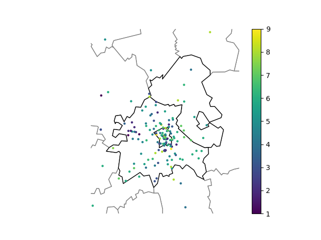

Locations mentioned by sentiment

## Key points raised in support

### Climate change

- Support for the development of a lively city district east of Milton Road, emphasizing the need for affordable housing and community facilities.
- Advocacy for the expansion of the Cambridge Biomedical Campus with additional healthcare facilities and housing.
- Emphasis on creating a carbon-neutral environment and promoting sustainable transport options.

### Biodiversity and green spaces

- Support for integrating green spaces and wildlife areas in new developments, particularly around the Cambridge Biomedical Campus.
- Advocacy for the preservation of existing green spaces and the creation of new parks and community gardens.

### Wellbeing and social inclusion

- Emphasis on the need for community facilities, such as schools, parks, and shops, to enhance local quality of life.
- Support for affordable housing to ensure that key workers and families can live within the community.

### Jobs

- Advocacy for the development of local job opportunities, particularly in healthcare and research sectors, to support the growing population.

### Infrastructure

- Support for improved public transport links and active travel routes to enhance connectivity and reduce reliance on cars.
- Emphasis on the need for adequate infrastructure to support new housing developments, including schools and healthcare facilities.

## Key points raised in opposition

### Climate change

- Concerns about the potential for increased traffic and pollution due to overdevelopment, particularly in rural areas.
- Opposition to the expansion of the Cambridge Biomedical Campus if it leads to further environmental degradation.

### Biodiversity and green spaces

- Strong opposition to any development that encroaches on greenbelt land or existing natural habitats, emphasizing the need to protect these areas.
- Concerns about the loss of wildlife and the need for biodiversity net gain in new developments.

### Wellbeing and social inclusion

- Opposition to significant housing developments in villages, arguing that they threaten the character and identity of these communities.
- Concerns about the adequacy of local services and infrastructure to support new housing, particularly in rural areas.

### Jobs

- Skepticism about the ability of new developments to create sufficient local job opportunities, particularly in light of changing work patterns post-pandemic.

### Infrastructure

- Concerns about the current state of public transport and the need for improvements before further housing developments are approved.
- Opposition to developments that do not adequately consider the impact on existing infrastructure, particularly in terms of traffic congestion and public services.

## Summaries

The author objects to the proposed housing developments on sites H/1:b and H/1:c due to concerns about inadequate infrastructure, particularly regarding traffic congestion and parking in Sawston. They argue that the developments conflict with national policy on protecting greenbelt land and ensuring the vitality of town centres. The author supports the development of a brownfield site (H/1:a) but believes that the additional developments would strain local resources.

**Stance**: OPPOSE

**Constructiveness**: 4

The author expresses mixed support for the SCDC Local Plan H/1e housing site off New Rd, endorsing the Green spaces policies but questioning the development’s ability to meet local needs and suggesting there are better alternatives. They also support the decision to exclude certain housing site options from the Draft Local Plan.

**Stance**: MIXED

**Constructiveness**: 6

The author objects to the proposed developments at Bourn Airfield and West Cambourne, citing concerns about disproportionate housing growth, traffic congestion, and environmental impacts. They argue that the area cannot support the additional homes and that the burden of development should be more evenly distributed across South Cambridgeshire. The author also supports the rejection of the North Cambourne development due to its impact on agricultural land, landscape, drainage issues, and traffic problems.

**Stance**: OPPOSE

**Constructiveness**: 4

The author supports the inclusion of public bridleways in the Green Infrastructure policy, arguing that they enhance community enjoyment and reduce traffic by providing leisure routes for walkers, riders, and cyclists. They suggest that well-designed bridleways can benefit all users and advocate for their inclusion in the Longstanton area, emphasizing the importance of conservation and green separation.

**Stance**: SUPPORT

**Constructiveness**: 9

The author has enclosed representations regarding their support or objection to the policy, paragraph, or site but does not provide specific comments in the response. The main issues raised are summarized in the enclosed representations.

**Stance**: NEUTRAL

**Constructiveness**: 5

The author supports the policy on affordable housing, emphasizing the need for a 40% provision of affordable homes in developments of three or more units. However, they express concern that the policy may not be effective in practice within a group village context.

**Stance**: SUPPORT

**Constructiveness**: 7

The response includes attached representations but does not provide specific comments or opinions regarding the planning application.

**Stance**: NEUTRAL

**Constructiveness**: 1

The author supports the inclusion of Lupin and Merton fields as local green spaces and suggests that a corner of Merton field be developed as a play area for children, while also advocating for the management of Lupin field as a wildlife area. They express concern about losing these green spaces amidst new housing developments.

**Stance**: SUPPORT

**Constructiveness**: 7

The author, representing the Swavesey & District Bridleways Association, expresses concern that the South Cambs Local Plan overlooks the needs of horseriders and non-motorised users (NMUs). They advocate for the inclusion of equestrian access in the Local Plan, highlighting the benefits of reducing road traffic, supporting local businesses, and promoting community wellbeing through improved access to green spaces. The author supports comments made by another group regarding the need for inclusive routes and compliance with national planning policy. They urge for revisions to the Local Plan to better accommodate NMUs and enhance local infrastructure.

**Stance**: OPPOSE

**Constructiveness**: 7

The response is directed to multiple stakeholders regarding a planning application, but does not provide specific feedback or opinions on the application itself. It appears to be more of an administrative communication rather than a substantive response to the planning proposal.

**Stance**: NEUTRAL

**Constructiveness**: 5

The author supports increased housing development in villages, particularly Fen Ditton, arguing that it would provide a suitable range of dwellings and enhance community services while maintaining green belt integrity. They suggest that Fen Ditton should be designated as a Minor Rural Centre and propose a specific site for modest development with associated green space improvements.

**Stance**: SUPPORT

**Constructiveness**: 8

The author opposes the development due to a lack of infrastructure to support the increased population, including concerns about traffic, schools, and healthcare facilities. They also question the necessity of the development in the area.

**Stance**: OPPOSE

**Constructiveness**: 3

The response from RES UK and Ireland Limited expresses support for the overall aims of the South Cambridgeshire Local Plan regarding climate change and renewable energy. However, it critiques the current policy framework for not adequately promoting renewable and low carbon energy development, suggesting amendments to align with national planning guidelines. RES emphasizes the importance of integrating renewable energy generation into planning to achieve sustainable economic growth and environmental goals, while also addressing concerns about decommissioning policies for energy projects.

**Stance**: MIXED

**Constructiveness**: 7

The author strongly opposes Policy CC/2 of the Local Plan due to its proposed minimum separation distance of 2km between wind turbines and dwellings, arguing that it is overly restrictive and not compliant with national policy. They emphasize the importance of promoting renewable energy development and suggest that the potential impacts should be assessed on a site-by-site basis rather than through inflexible rules. The author supports Policy CC/3, which encourages the use of renewable energy in new developments, and expresses a desire for better wording in the objectives to reflect the importance of renewable energy in addressing climate change.

**Stance**: OPPOSE

**Constructiveness**: 4

The author argues that the proposed policy is unsound because it imposes inflexible rules on separation distances, which contradicts the Planning Practice Guidance for Renewable and Low Carbon Energy. They claim the policy is not positively planned, justified, or consistent with national planning policy.

**Stance**: OPPOSE

**Constructiveness**: 4

The author opposes the redevelopment of the waste water treatment plant, expressing concerns about relocating it to a greenfield site. They also oppose any development that would encroach on the green belt, including around the Cambridge Biomedical Campus and in the southern rural cluster of villages. The author advocates for limited development in villages without improved public transport and envisions a densified, vehicle-free city that does not sprawl onto the green belt.

**Stance**: OPPOSE

**Constructiveness**: 3

The author supports the designation of site 078 as Local Green Space, highlighting its importance to the Bassingbourn community and its integration with existing green areas. They argue that development would harm the character of the village and remove a valuable amenity. The designation is backed by the SCDC assessment and the Parish Council.

**Stance**: SUPPORT

**Constructiveness**: 9

The author supports the development of a lively and dense city district east of Milton Road, emphasizing the need for facilities that promote a circular economy, such as allotments and community centers, and advocates for car-free development. They also support the expansion of the Cambridge Biomedical Campus with more healthcare facilities but no additional housing. The author suggests safe cycling routes to Cambridge for Cambourne’s growth and expresses a preference for limited development in villages, contingent on car-free designs and safe cycling routes. They propose more open green spaces and improved walking and cycling routes in villages and identify a site north of Barton Road for potential development. Overall, the author envisions a car-free Greater Cambridge by 2041.

**Stance**: SUPPORT

**Constructiveness**: 9

The author expresses strong opposition to various proposed developments in Greater Cambridge, emphasizing the need to prioritize existing infrastructure and preserve green spaces. They reject the idea of developing the area east of Milton Road, oppose the East-West Rail link, and advocate for limited development in villages unless existing infrastructure is adequate. Overall, the response highlights a desire to maintain the current landscape and avoid additional strain on resources.

**Stance**: OPPOSE

**Constructiveness**: 2

The author advocates for the development of community spaces, green spaces, and affordable housing across various locations including North East Cambridge, the Cambridge Biomedical Campus, Cambourne, and the southern rural cluster of villages. They also emphasize the importance of active transport and low emission zones for Greater Cambridge’s future.

**Stance**: SUPPORT

**Constructiveness**: 9

The author expresses strong opposition to various proposed developments in Greater Cambridge, particularly in Cambourne and Highfields Caldecote, citing concerns over the destruction of local character, increased crime, and inadequate facilities. They advocate for more open spaces and nature, and criticize the current housing developments as unattractive and unaffordable. The author emphasizes the need for better local facilities rather than more housing, and expresses a desire to maintain the rural landscape.

**Stance**: OPPOSE

**Constructiveness**: 2

The author envisions the area east of Milton Road in North East Cambridge as a vibrant city district post-relocation of the waste water treatment plant, emphasizing the need for housing, jobs, and open spaces. They advocate for the East-West Rail to be centrally located in Cambourne to enhance accessibility and support local economic growth, while also calling for improved services such as healthcare and education. The author stresses the importance of maintaining open spaces and natural habitats in the southern rural cluster and expresses concern over development in villages like Caldecote, which lacks public transport. They suggest clear borders between villages to preserve their character and promote wildlife. The author hopes for Greater Cambridge to retain its green spaces and low-rise developments by 2041.

**Stance**: MIXED

**Constructiveness**: 7

The author expresses no specific suggestions or opinions regarding the development of various areas in Greater Cambridge, including the Cambridge Biomedical Campus, Cambourne, and the southern rural cluster of villages. They do not provide any input on housing, jobs, facilities, or open spaces for these locations.

**Stance**: NEUTRAL

**Constructiveness**: 1

The author expresses strong opposition to various proposed developments in Greater Cambridge, emphasizing concerns about the loss of green spaces and the impact of increased housing on rural areas. They specifically criticize the development around the Cambridge Biomedical Campus for encroaching on open spaces and express skepticism about the East-West Rail project, viewing it as a catalyst for excessive housing development. The author advocates for limited development in villages, stressing the need for sustainability and caution against overdevelopment that could compromise the rural character of the area.

**Stance**: OPPOSE

**Constructiveness**: 2

The author expresses strong opposition to the proposed developments in Greater Cambridge, emphasizing the need to prioritize environmental concerns, particularly regarding water resources and biodiversity. They advocate for limiting development to brownfield sites and ensuring that any new housing is affordable and equitably distributed across communities. The response highlights the importance of preserving farmland and natural habitats, criticizing the current approach to development as unsustainable and detrimental to the environment.

**Stance**: OPPOSE

**Constructiveness**: 2

The author expresses apprehension about the development of a dense city district east of Milton Road, suggesting caution regarding over-expansion. They support the development of the Cambridge Biomedical Campus but advocate for careful planning and limits on development. The author questions the necessity of more jobs in Cambourne with the East-West Rail link and expresses concern about saturation in the southern rural cluster of villages. They suggest limited development in villages and emphasize the need for radical action to reduce motor traffic and prioritize climate change in planning for the future.

**Stance**: MIXED

**Constructiveness**: 6

The author advocates for limited development in villages, suggesting that new development should only occur in those with existing local services, particularly healthcare access.

**Stance**: SUPPORT

**Constructiveness**: 7

The author suggests developing the area east of Milton Road into a vibrant city district with necessary facilities like schools and community spaces. They support the expansion of the Cambridge Biomedical Campus with additional healthcare and green spaces. The author expresses a desire for Cambourne to develop into a proper town with similar facilities, but shows disinterest in further questions about development in villages, indicating a preference for limited development in those areas. Overall, the response lacks enthusiasm and detail.

**Stance**: MIXED

**Constructiveness**: 5

The author proposes a range of community facilities and green spaces for various development areas, emphasizing the need for inclusive recreational spaces, biodiversity initiatives, and support for local businesses. They advocate for healthcare facilities and community engagement in the Cambridge Biomedical Campus area, and suggest similar amenities for the East-West Rail and Cambourne developments. The response highlights the importance of creating vibrant, accessible spaces for all ages and promoting environmental sustainability.

**Stance**: SUPPORT

**Constructiveness**: 9

The author proposes a variety of community facilities and green spaces aimed at enhancing recreation, biodiversity, and social inclusion. They emphasize the need for shared spaces, outdoor facilities, and support for local businesses, while also calling for the retention and strengthening of specific policies in the Cambridge Local Plan.

**Stance**: SUPPORT

**Constructiveness**: 9

The author supports the development of the Cambridge Biomedical Campus for healthcare, research, and housing, suggesting the creation of semi-natural areas linked to Hobson’s Park. However, they oppose the current East-West Rail route and advocate for better, larger, and more connected wild areas in Greater Cambridge by 2041.

**Stance**: MIXED

**Constructiveness**: 6

The author supports the development of a lively and dense city district east of Milton Road in North East Cambridge, emphasizing the need for efficient transport links and local amenities. They advocate for the expansion of the Cambridge Biomedical Campus with additional healthcare facilities and housing, stressing the importance of transport capacity. The author also highlights the necessity of good transport options for the growth of Cambourne and the southern rural cluster of villages, while suggesting that Greater Cambridge should take inspiration from the Netherlands for future development.

**Stance**: SUPPORT

**Constructiveness**: 9

The author supports the development of various areas in Greater Cambridge, emphasizing the need for more housing, improved cycling infrastructure, and healthcare facilities. They advocate for prioritizing homes over jobs in the Cambridge Biomedical Campus and suggest that villages with good transport links should see new development. The author also criticizes the current use of land in the Newmarket Road area, calling for it to be repurposed for housing and community spaces. Overall, they align with the vision of high environmental standards and reduced car dependency.

**Stance**: SUPPORT

**Constructiveness**: 9

The author expresses strong opposition to the proposed developments in various areas, advocating for the protection of natural spaces and emphasizing the need for rewilding and environmental conservation. They argue against further urbanization, particularly in beautiful rural areas, and highlight the importance of preserving open spaces and addressing pollution issues. The author also suggests revitalizing existing urban areas rather than expanding into rural land, and calls for more trees and public footpaths in Greater Cambridge.

**Stance**: OPPOSE

**Constructiveness**: 2

The author opposes any further development in Greater Cambridge, expressing concerns about the strain on the city’s infrastructure and the impact on its character. They reject proposals for development in various areas, including North East Cambridge, the Cambridge Biomedical Campus, Cambourne, and surrounding villages, insisting that no additional housing, jobs, or facilities should be created.

**Stance**: OPPOSE

**Constructiveness**: 2

The author expresses strong opposition to various proposed developments in Greater Cambridge, advocating for the preservation of open spaces and the green belt. They suggest that the area east of Milton Road could be developed after relocating the waste water treatment plant but emphasize the need for adequate parking. They oppose further development around the Cambridge Biomedical Campus due to existing congestion and advocate for limited development in villages, insisting on maintaining open spaces and rejecting additional housing. The author also calls for the scrapping of the East-West Rail project unless it is electrified, and expresses a desire for Greater Cambridge to remain unchanged, criticizing the unelected Greater Cambridge Partnership (GCP).

**Stance**: OPPOSE

**Constructiveness**: 2

The author advocates for the development of various areas in Greater Cambridge, emphasizing the need for socially inclusive housing that accommodates tradespeople and local employment opportunities. They suggest that developments should not solely focus on office-based jobs and should include facilities that support local communities. The author also expresses concern about maintaining the ecosystem of village life and the importance of considering electrical power generation and resilience against climate risks.

**Stance**: SUPPORT

**Constructiveness**: 9

The author expresses skepticism about developing a dense city district east of Milton Road, citing a preference for outdoor spaces post-pandemic. They support the expansion of the Cambridge Biomedical Campus for local jobs and healthcare facilities but emphasize the need for jobs accessible to local residents. The author is uncertain about the current state of Cambourne and the southern rural cluster for development, suggesting limited development in villages with good transport links, specifically mentioning Waterbeach for better shopping facilities.

**Stance**: MIXED

**Constructiveness**: 6

The author advocates for the development of green, natural parks with trees and lakes in various areas including North East Cambridge, around the Cambridge Biomedical Campus, Cambourne, and the southern rural cluster of villages. They express a preference for limited development in villages, suggesting no new housing or facilities in those areas. Overall, the response emphasizes the importance of green spaces in future developments.

**Stance**: SUPPORT

**Constructiveness**: 9

The author strongly opposes the proposed developments in various areas, expressing concerns that they will lead to overdevelopment and negatively impact the character of Cambridge and its surrounding villages. They argue that the city is already overdeveloped and that further construction will ruin its beauty and livability.

**Stance**: OPPOSE

**Constructiveness**: 2

The author strongly opposes the proposed development in North East Cambridge, arguing that the relocation of the sewage works is profit-driven and unnecessary, as the current facility has sufficient capacity until 2050. They criticize the lack of transparency regarding the sewage works’ status as a nationally significant infrastructure project and express concern over the potential loss of Green Belt land. The author also critiques the approach to housing development in Cambourne and surrounding areas, advocating for gradual, small-scale development rather than large, impersonal projects. They emphasize the importance of community integration and the historical success of small developments in fostering strong communities.

**Stance**: OPPOSE

**Constructiveness**: 2

The author expresses concerns about proposed developments in various areas, emphasizing the need for adequate water management, public transport, and preservation of existing green spaces. They oppose dense housing developments and suggest limiting new developments in villages, advocating for the enhancement of open spaces instead.

**Stance**: OPPOSE

**Constructiveness**: 4

The author expresses concerns about various proposed developments in Greater Cambridge, particularly regarding the need for appropriate housing and facilities that cater to the local community. They support the development of the Cambridge Biomedical Campus but criticize the current state of Addenbrooke’s and the impact of housing prices on local residents. The author is critical of the East-West Rail project, viewing it as detrimental to local communities and suggesting that tram systems would be more effective. They advocate for limited development in villages, emphasizing the importance of public transport and local services. Overall, the response reflects skepticism about the planning process and the need for more community-focused development.

**Stance**: OPPOSE

**Constructiveness**: 4

The author expresses concerns about various proposed developments in Greater Cambridge, advocating for limited housing in green belt areas and emphasizing the need for more healthcare facilities and amenities around existing sites like the Cambridge Biomedical Campus. They support the idea of developing a lively city district east of Milton Road but oppose further housing at Addenbrookes due to overcrowding. The author also suggests that Cambourne should grow with adequate facilities while maintaining existing natural spaces in surrounding villages.

**Stance**: OPPOSE

**Constructiveness**: 4

The author suggests that the area east of Milton Road in North East Cambridge, currently housing a waste water treatment plant, has potential for development into a vibrant city district, emphasizing the need for parks and open spaces in the planning.

**Stance**: SUPPORT

**Constructiveness**: 7

The author supports the development of various areas in Greater Cambridge, emphasizing the need for affordable housing, improved public transport, and enhanced facilities such as schools, healthcare, and recreational spaces. They advocate for sustainable features like solar panels and EV charging points in new homes, and express a desire for better connectivity between villages and the city. Concerns are raised about the current capacity of local services and the need for careful planning in rural areas.

**Stance**: SUPPORT

**Constructiveness**: 9

The author advocates for the development of various areas in Greater Cambridge, emphasizing the need for social housing accessible to all, particularly in North East Cambridge and Cottenham. They support the expansion of the Cambridge Biomedical Campus with more healthcare facilities and single-person housing. The author suggests Cambourne should focus on housing and small businesses rather than additional open spaces. They express concerns about restrictions on housing in villages, arguing for more inclusivity and the need for better local amenities and transport connections.

**Stance**: SUPPORT

**Constructiveness**: 8

The author expresses strong opposition to the proposed developments in various areas, arguing that the density of housing in North East Cambridge could lead to future slum conditions, that the Cambridge Biomedical Campus should focus solely on biomedical uses without housing, and that Cambourne has already taken on enough housing without additional development. They emphasize the need for sustainable housing, necessary facilities before any new housing, and the preservation of existing leisure areas.

**Stance**: OPPOSE

**Constructiveness**: 2

The author expresses strong opposition to the expansion of the Cambridge Biomedical Campus, advocating for a more balanced development approach across the region. They criticize the East-West Rail project as inadequate for local needs and emphasize the necessity of improving transport infrastructure before any further development in southern villages. The author calls for greater outdoor recreational facilities and a diversified economic base to reduce reliance on biotech industries. They envision Greater Cambridge as a leader in environmental action and social well-being by 2041.

**Stance**: OPPOSE

**Constructiveness**: 4

The author strongly opposes the proposed development in North East Cambridge, arguing that relocating the waste water treatment plant is unnecessary and financially unfeasible. They express concerns about the impact on green belt and agricultural land, describing the development as destructive to the local community and conservation areas. The author also dismisses the need for additional healthcare facilities at the Cambridge Biomedical Campus, criticizes the affordability of rail travel for Cambourne, and advocates for limited development in villages, emphasizing the importance of listening to local populations. Overall, they express a belief that the push for development is eroding communities and distancing people from democratic processes.

**Stance**: OPPOSE

**Constructiveness**: 2

The author suggests that the area east of Milton Road in North East Cambridge should be developed into a vibrant city district with more open space than currently proposed. They also emphasize the need for improved transport infrastructure, including bike parking, safe pedestrian routes, and reliable public transport services.

**Stance**: MIXED

**Constructiveness**: 7

The author opposes further development in Melbourn, citing recent housing increases that have outstripped local infrastructure, particularly in healthcare and education. They advocate for leaving the village unchanged.

**Stance**: OPPOSE

**Constructiveness**: 4

The author expresses support for the development of specific areas in Greater Cambridge, including the east of Milton Road and the Cambridge Biomedical Campus, emphasizing the need for housing, jobs, and facilities. However, they raise concerns about the development in Cambourne, questioning the definition of a ‘proper town’ and advocating for more retail options without major developments north of the A428. They agree with limited development in villages, stressing the importance of maintaining village character and prioritizing brownfield sites for housing over greenfield sites.

**Stance**: MIXED

**Constructiveness**: 6

The author expresses a desire for the development of affordable and social housing in North East Cambridge and supports the expansion of the Cambridge Biomedical Campus with additional healthcare facilities and housing. They express uncertainty about development in Cambourne and the southern rural cluster of villages, emphasizing the need for good public transport connections. The author raises concerns about the potential negative impacts of development on the quality of life for existing residents, particularly regarding congestion and infrastructure needs.

**Stance**: MIXED

**Constructiveness**: 6

The author supports the development of the Cambridge Biomedical Campus with additional healthcare facilities, research, and housing. They suggest that Cambourne should develop into a proper town with healthcare jobs and facilities. They advocate for mixed and lower-cost housing in Shelford/Stapleford due to good access to the biomedical campus, along with a supermarket and recreation facilities. The author believes development in villages should be limited, with specific mentions of Shelford/Stapleford and Duxford. They emphasize the importance of maintaining the distinction between city and villages, improving planning for electric vehicles, and addressing public transport challenges in small villages.

**Stance**: SUPPORT

**Constructiveness**: 9

The author expresses strong opposition to various proposed developments in Greater Cambridge, arguing that they would lead to a loss of open spaces and the unique character of the area. They specifically criticize the idea of a dense city district, the expansion of the Cambridge Biomedical Campus, and any development near the East-West Rail line, particularly if it involves diesel trains. The author advocates for preserving the historical architecture and character of Cambridge rather than allowing modern, high-rise buildings.

**Stance**: OPPOSE

**Constructiveness**: 2

The author expresses opposition to relocating the wastewater treatment plant, arguing it would waste money and green belt land. They support the development of the Cambridge Biomedical Campus but call for improved safety for pedestrians and cyclists. The author advocates for greener technologies in rural villages and opposes development on green belt land. They suggest improvements for Fen End Road and emphasize the need for more green spaces, trees, and better public transport in Greater Cambridge by 2041.

**Stance**: OPPOSE

**Constructiveness**: 4

The author suggests that Cambourne should develop into a proper town with amenities such as a swimming pool, adventure playground, and more retail options. They advocate for limited development in villages, recommending places like Gamlingay and Bourn for new developments. The author also identifies Barton as a potential site for housing or business use and expresses a desire for more affordable parking and out-of-town shopping areas, along with country parks to enhance the countryside experience.

**Stance**: SUPPORT

**Constructiveness**: 8

The author expresses a vision for the development of various areas in Greater Cambridge, advocating for the creation of essential facilities such as schools, healthcare services, community spaces, and leisure options. They support the development of the Cambridge Biomedical Campus and the growth of Cambourne into a proper town, emphasizing the need for better transport links. However, they oppose development in the southern rural cluster of villages and advocate for using only brownfield sites for new developments, while preserving the rural character of the county.

**Stance**: MIXED

**Constructiveness**: 6

The author expresses frustration over the lack of promised infrastructure and facilities in Cambourne, highlighting the absence of a high street, swimming pool, and adequate jobs, which forces residents to travel to Cambridge. They call for improvements in public transport and the development of entertainment venues and retail parks to reduce reliance on car travel.

**Stance**: OPPOSE

**Constructiveness**: 4

The author expresses support for the development of a lively city district east of Milton Road and the Cambridge Biomedical Campus, advocating for a mixture of housing, jobs, facilities, and open spaces. They also support the growth of Cambourne into a proper town with similar mixed developments. However, they oppose any development in the southern rural cluster of villages and emphasize the need for limited development in villages, particularly those with good public transport. Additionally, they highlight the necessity of addressing traffic issues in Greater Cambridge.

**Stance**: MIXED

**Constructiveness**: 6

The author expresses strong opposition to various proposed developments in Greater Cambridge, emphasizing the need to protect green spaces and rural villages. They support limited development on brownfield sites but reject any development on green land, citing concerns about climate change and the importance of nature for health. They advocate for improved transport links and local services but are critical of large-scale developments that could harm the environment.

**Stance**: OPPOSE

**Constructiveness**: 4

The author supports the development of the Cambridge Biomedical Campus for healthcare, research, and housing, emphasizing the need for high-quality jobs and affordable housing. They advocate for Cambourne to develop into a proper town with affordable housing for graduates. The response highlights the need for improved links and facilities in the southern rural cluster of villages, suggesting better access and amenities. The author expresses concern about overdevelopment in villages and suggests developing areas with poor amenities instead. They propose a new pedestrian route and cycle path in Meldreth and support the development of a new village at Heydon Golf Course. Overall, the author envisions Greater Cambridge as a more affordable place for young people with more family-friendly activities.

**Stance**: SUPPORT

**Constructiveness**: 9

The author supports the development of various areas in Greater Cambridge, including the east of Milton Road, the Cambridge Biomedical Campus, and Cambourne, emphasizing the need for diverse shops, affordable housing, and healthcare facilities. They advocate for limited development in villages with good transport links and suggest potential sites for development along the A1307. Overall, the response highlights the importance of local identity, accessibility, and community needs in planning.

**Stance**: SUPPORT

**Constructiveness**: 9

The author expresses concerns about the appropriateness of further development in the congested area east of Milton Road in North East Cambridge. They support the development of the Cambridge Biomedical Campus, suggesting improvements in public transport, local shops, and a range of housing. They advocate for growth in Cambourne, emphasizing the need for more shops and a cottage hospital. The author suggests limited development in the southern rural cluster of villages, proposing more housing along the Cambridge Royston railway and a regional shopping/sports center. They recommend specific villages for new development and improvements in shopping and transport services. Lastly, they envision Greater Cambridge as a world-leading center of technical excellence by 2041, with suitable homes and environment.

**Stance**: MIXED

**Constructiveness**: 7

The author suggests that the southern rural cluster of villages near the rail line and business parks south of Cambridge could accommodate limited development, specifically highlighting the need for more schools and GPs in the area.

**Stance**: SUPPORT

**Constructiveness**: 7

The author expresses strong opposition to any development in Greater Cambridge, advocating against housing expansion and the development of land in villages, emphasizing a desire to maintain the current character of these areas.

**Stance**: OPPOSE

**Constructiveness**: 2

The author advocates for the development of a vibrant city district east of Milton Road in North East Cambridge, emphasizing the need for outdoor entertainment and sports facilities to promote health. They also support the expansion of the Cambridge Biomedical Campus with additional healthcare facilities and housing, while expressing frustration over the current state of environmentally sustainable transport and housing.

**Stance**: SUPPORT

**Constructiveness**: 7

The author argues against the proposed development in North East Cambridge, stating that the relocation of the Waste Water Treatment Works is unnecessary and should not be a condition for the development.

**Stance**: OPPOSE

**Constructiveness**: 4

The author expresses skepticism about the development plans for the area east of Milton Road, suggesting that it may lead to overpopulation and benefit current residents financially. They also support the development of the Cambridge Biomedical Campus but emphasize that housing should primarily be for workers.

**Stance**: MIXED

**Constructiveness**: 5

The author emphasizes the need for more parks and safe play spaces in and around the villages, highlighting the importance of recreational areas for the community.

**Stance**: SUPPORT

**Constructiveness**: 7

The author strongly opposes any further housing development in Cambourne, citing a lack of resources and increasing traffic issues, and believes that the original vision of interconnected villages has been lost as Cambourne has already developed into a town.

**Stance**: OPPOSE

**Constructiveness**: 2

The author strongly opposes any new development in Greater Cambridge, expressing a desire to maintain the current state of the area and criticizing the council for their actions. They specifically reject the idea of additional housing, jobs, or facilities in various proposed developments, including the Cambridge Biomedical Campus and Cambourne, and call for a halt to all building activities.

**Stance**: OPPOSE

**Constructiveness**: 2

The author advocates for high-density development in various areas of Greater Cambridge, including the east of Milton Road, around the Cambridge Biomedical Campus, Cambourne, and the southern rural cluster of villages. They emphasize the need for more housing to address shortages, reduce commuting, and support local economies. The response also suggests utilizing existing retail spaces for housing and promoting active travel in the future.

**Stance**: SUPPORT

**Constructiveness**: 9

The author opposes the development of various areas around Cambridge, arguing that existing facilities like the waste water treatment plant should remain and that villages should be protected from further development. They emphasize the need for green spaces and improved environments for walking and biking rather than new housing or business developments.

**Stance**: OPPOSE

**Constructiveness**: 3

The author expresses strong opposition to the proposed development in North East Cambridge, criticizing the lack of environmental consideration, inadequate public transport, and the potential destruction of green spaces. They advocate for lower density, more green spaces, and better public transport options. The response also highlights concerns about the overdevelopment of Cambridge and the need to protect the green belt, while suggesting that development should focus on areas that require support rather than those already overwhelmed by construction.

**Stance**: OPPOSE

**Constructiveness**: 2

The author supports the development of a lively and dense city district east of Milton Road in North East Cambridge, emphasizing the need for a mix of housing types, jobs, schools, and recreational open spaces. They also advocate for the expansion of the Cambridge Biomedical Campus with additional healthcare facilities and housing, while suggesting that Cambourne needs improvements to its environment. The author expresses skepticism about new developments in villages, indicating that residents may not favor them.

**Stance**: SUPPORT

**Constructiveness**: 7

The author expresses no opinion on the development east of Milton Road but supports the Cambridge Biomedical Campus expansion, emphasizing the need to protect the Magog hills. They advocate for the East-West Rail project to enhance transport links to Cambourne, criticizing the lack of local facilities and calling for a proper town center. The author suggests that villages should not be overdeveloped, with some planned expansions being acceptable, and highlights the need for improved public transport services. They also express concerns about the cramped housing developments in Upper Cambourne and the importance of green spaces for wildlife and mental health. Finally, they argue for better transport options to reduce car use in commuter towns.

**Stance**: MIXED

**Constructiveness**: 7

The author opposes the development of the area east of Milton Road due to the recent upgrade of the wastewater treatment plant and the high costs of relocation. They advocate for housing to be built at the site of the relocated plant instead. They support the development of the Cambridge Biomedical Campus with a focus on vast open spaces and community centers, while opposing development in Cambourne and the southern rural cluster of villages. They suggest limited development in villages with good transport connections and mention Grantchester as a potential site. The author emphasizes the need for road bypasses and expresses a desire for Greater Cambridge to remain underdeveloped and preserved by 2041.

**Stance**: OPPOSE

**Constructiveness**: 4

The author expresses strong opposition to various proposed developments in Greater Cambridge, particularly criticizing the urbanization and expansion plans for areas like Cambourne and the southern rural cluster of villages. They advocate for limited development in villages with good transport links and express a desire for more green spaces and better transport options. Overall, the author is concerned about the impact of urban sprawl and pollution on the region.

**Stance**: OPPOSE

**Constructiveness**: 2

The author supports the development of various areas in Greater Cambridge, emphasizing the need for affordable housing, healthcare facilities, schools, and retail spaces. They express concerns about the current insufficiency of medical services and educational capacity in Cambourne due to ongoing developments. The author advocates for limited development in villages, focusing on those with existing amenities, and suggests increasing capacity in local services. They also call for a reduction in large luxury homes in future developments.

**Stance**: SUPPORT

**Constructiveness**: 8

The author expresses a vision for the development of the area east of Milton Road in North East Cambridge, advocating for a lively city district post-relocation of the waste water treatment plant, and supports the expansion of the Cambridge Biomedical Campus with more healthcare facilities and parkland. However, they oppose further housing development in Cambourne, emphasizing the need to preserve ancient woodlands and farmland, and suggest that villages should see no new development, advocating instead for open spaces. The author also expresses skepticism about the planning process, suggesting a lack of transparency.

**Stance**: MIXED

**Constructiveness**: 6

The author supports the development of a lively city district east of Milton Road in North East Cambridge, emphasizing the need for a strong cycle network and small homes. They also advocate for the expansion of the Cambridge Biomedical Campus with more healthcare facilities and housing, and express full support for the East-West Rail project past Cambourne. Additionally, they highlight the need for a cycle network and small homes in the southern rural cluster of villages. The author calls for more forested areas in the region and suggests local councils enforce pesticide-free zones, while also seeking assistance in connecting with landowners for forest development.

**Stance**: SUPPORT

**Constructiveness**: 9

The author expresses strong opposition to the proposed developments in Greater Cambridge, arguing that they would lead to the destruction of green spaces and exacerbate climate change. They advocate for preserving open spaces and planting more trees instead of replacing them with housing and industrial units.

**Stance**: OPPOSE

**Constructiveness**: 2

The author expresses no opinion on various proposed developments in Greater Cambridge, including the area east of Milton Road, the Cambridge Biomedical Campus, Cambourne, the southern rural cluster of villages, and potential sites for housing or business use. They also do not provide any thoughts on the future vision for Greater Cambridge in 2041.

**Stance**: NEUTRAL

**Constructiveness**: 1

The author supports the development of the Cambridge Biomedical Campus with a focus on affordable housing for essential workers. They express concern about overdevelopment in the northern and western areas of Cambridge, advocating for significant development in the southern region to improve transport links and reduce reliance on cars. The author believes that villages in the south should also accommodate development similar to that in the north, particularly near railway lines and the East-West rail link. They emphasize the need for infrastructure to support car use until public transport becomes more reliable and affordable.

**Stance**: SUPPORT

**Constructiveness**: 8

The author expresses concerns about the proposed housing density in North East Cambridge, fearing it will diminish the quality of life and the city’s character. They advocate for more cultural and social spaces around the Cambridge Biomedical Campus and suggest a balanced mix of employment opportunities in Cambourne. The author also supports limited development in villages and calls for a more distributed approach to development rather than concentrating it in Cambridge. Overall, they feel that the current development plans are excessive.

**Stance**: OPPOSE

**Constructiveness**: 4

The author expresses skepticism about relocating the wastewater treatment facility and supports the development of the Cambridge Biomedical Campus with more housing and green spaces. They suggest re-establishing rail stations in Cherry Hinton and extending connections to nearby villages, while advocating for improved public transport links to facilitate development in more villages.

**Stance**: MIXED

**Constructiveness**: 6

The author expresses agreement with the potential for Cambourne to develop into a proper town, emphasizing the need for solar panels and centralized water storage in new housing. However, they oppose any significant development in the southern rural cluster of villages, advocating for minimal changes to preserve village life and the surrounding beauty. They also highlight that existing facilities and open spaces in villages are sufficient and caution against further development that could detract from the area’s character.

**Stance**: OPPOSE

**Constructiveness**: 4

The author envisions the area east of Milton Road in North East Cambridge as a vibrant city district with cultural facilities like a major theatre and artists’ studios, alongside outdoor spaces for sports and health. They advocate for Cambourne to develop into a proper town with leisure facilities and green spaces, while opposing the transformation of border villages into suburbs, suggesting instead to expand standalone villages with good transport links. The author emphasizes the importance of facilitating local businesses to recruit locally.

**Stance**: MIXED

**Constructiveness**: 7

The author expresses strong opposition to the proposed developments in Greater Cambridge, citing concerns about overcrowding, inadequate infrastructure, and environmental impacts such as air quality. They advocate for more open spaces, affordable public transport, and housing that promotes social inclusion. The response emphasizes the need for cleaner transportation options and better planning to avoid negative consequences for the community.

**Stance**: OPPOSE

**Constructiveness**: 2

The author supports the development of a lively and dense city district east of Milton Road in North East Cambridge, emphasizing the need for ample public open space to benefit both new and existing residents. However, they oppose further development at the Cambridge Biomedical Campus, citing sufficient existing development in the green belt. They suggest Sawston as a promising location for limited village development and advocate for a network of travel hubs instead of park-and-ride facilities to promote car-free travel into Cambridge.

**Stance**: MIXED

**Constructiveness**: 7

The author advocates for the development of various areas in Greater Cambridge, emphasizing the importance of carbon net-zero initiatives, green spaces, and housing suitable for wheelchair users. They express a desire for a mix of housing, jobs, and facilities in proposed developments, while also highlighting the need for good public transport connections and the use of brownfield sites over greenfield sites.

**Stance**: SUPPORT

**Constructiveness**: 9

The author supports the development of the Cambridge Biomedical Campus for healthcare facilities, research, and housing but raises concerns about increased traffic congestion and the need for improved healthcare capacity. They advocate for limited development in villages with good transport links but believe all villages should be considered for development. The author highlights the strain on healthcare services due to population growth in Cambridge.

**Stance**: MIXED

**Constructiveness**: 6

The author expresses uncertainty regarding specific developments in various areas, including the potential for a city district east of Milton Road, the Cambridge Biomedical Campus, Cambourne, and the southern rural cluster of villages. They suggest limited development in villages with good public transport connections and emphasize the importance of public transport and healthcare facilities in planned developments. Overall, they find the current plan focusing on larger villages and towns to be sensible.

**Stance**: NEUTRAL

**Constructiveness**: 6

The author supports the development of the Cambridge Biomedical Campus, emphasizing the need for more affordable housing and additional healthcare facilities, research, and jobs in the area.

**Stance**: SUPPORT

**Constructiveness**: 7

The author expresses a strong limitation on development in villages, suggesting that only a few sites with good public transport and local services should be considered. They also emphasize the need for new developments to have character, criticizing recent developments near Adenbrookes for lacking this quality.

**Stance**: OPPOSE

**Constructiveness**: 4

The author expresses concerns about the lack of leisure facilities, healthcare services, and affordable housing in proposed developments in North East Cambridge and around the Cambridge Biomedical Campus. They advocate for the inclusion of local amenities in villages and emphasize the need for infrastructure to be established before any new developments. The author also criticizes the previous local plan for not improving Cambridge and suggests looking at other areas for development opportunities.

**Stance**: OPPOSE

**Constructiveness**: 4

The author supports the development of various areas in Greater Cambridge, including the east of Milton Road, the Cambridge Biomedical Campus, Cambourne, and the southern rural cluster of villages, while advocating for limited development in villages without adequate infrastructure. They emphasize the need for housing, jobs, facilities, and open spaces, particularly focusing on enhancing green spaces and community renewable energy projects. The author also expresses a vision for a carbon-neutral future with a thriving natural environment.

**Stance**: SUPPORT

**Constructiveness**: 9

The author supports the development of a lively city district east of Milton Road in North East Cambridge, emphasizing the need for cycle lanes, easy access to the river, and wild green spaces. They also advocate for local shops to avoid a sterile suburb feel. Additionally, they support the expansion of the Cambridge Biomedical Campus with more healthcare facilities and housing, while suggesting that villages should be hubs for development with good public transport and local services. They stress the importance of direct routes to essential shops and improved public transport connections to tourist sites.

**Stance**: SUPPORT

**Constructiveness**: 9

The author opposes development in the southern rural cluster of villages near Cambridge, emphasizing the need for improved public transport before considering any new housing or facilities. They argue that current transport options are inadequate and stress the importance of making public transport frequent, reliable, and affordable. The author also highlights the necessity for local amenities within walking distance for residents.

**Stance**: OPPOSE

**Constructiveness**: 4

The author opposes the proposed developments around the Cambridge Biomedical Campus, Cambourne, and the southern rural cluster, arguing that existing communities cannot support more housing and that there should be no intrusion on the green belt. They express concerns about the adequacy of local amenities and water resources, advocating for improvements to existing settlements rather than expansion.

**Stance**: OPPOSE

**Constructiveness**: 2

The author opposes the proposed development in the green belt area of Shelford/Stapleford, citing concerns about the merging of the villages, erosion of green belt protection, increased traffic, and safety risks. They suggest that housing should be planned in a more distant village to promote rail use instead of car dependency.

**Stance**: OPPOSE

**Constructiveness**: 4

The author expresses support for the development of a lively city district east of Milton Road after the relocation of the waste water treatment plant, advocates for more healthcare facilities and housing around the Cambridge Biomedical Campus, and suggests the reinstallation of the railway line between Haverhill and Cambridge to alleviate traffic issues. They agree that development should focus on new communities rather than altering existing villages and emphasize the need for improved broadband in rural areas to support remote work and reduce carbon footprints. The author also highlights the importance of catering housing needs to the skilled workforce in the area.

**Stance**: SUPPORT

**Constructiveness**: 9

The author supports the development of various areas in Greater Cambridge, emphasizing the need for mixed-use developments that include housing, jobs, healthcare facilities, and open spaces to foster community. They advocate for self-sufficiency in Cambourne and limited development in villages, focusing on brownfield sites to preserve local character. Essential services like schools and healthcare are highlighted as necessary for new developments.

**Stance**: SUPPORT

**Constructiveness**: 9

The author strongly opposes the proposed development in Great Shelford, citing concerns about the impact on green belt land, increased traffic, and pressure on local schools. They believe the development will not support sustainable travel and will primarily benefit developers rather than the community.

**Stance**: OPPOSE

**Constructiveness**: 3

The author opposes the relocation of the sewage works, arguing that it would harm green belt land. They also express concerns about traffic congestion around the Cambridge Biomedical Campus, suggesting that no further development should occur in that area.

**Stance**: OPPOSE

**Constructiveness**: 3

The author supports the development of a lively city district east of Milton Road with carbon-neutral housing and starter homes for families. They advocate for expanding the Cambridge Biomedical Campus with more healthcare facilities while preserving the Nine Wells nature reserve. They suggest developing Cambourne into a proper town with community hubs and access to greenery. The author expresses caution about limited development in villages to maintain their character and raises concerns about supporting remote work. They propose converting the Grafton Centre into housing with a design that fits Cambridge’s skyline. Lastly, they envision a safe town for future generations that contributes to environmental sustainability.

**Stance**: SUPPORT

**Constructiveness**: 9

The author suggests that all developments with more than 10 new homes should undergo a WLC assessment, arguing that the current threshold of 150 is too high. They also advocate for no new car parking facilities in new developments.

**Stance**: MIXED

**Constructiveness**: 6

The author opposes the proposed development in Shelford, arguing that it threatens the green belt and could lead to the merging of communities. They express concerns about insufficient access to the site and potential traffic issues, emphasizing the importance of preserving green belt areas.

**Stance**: OPPOSE

**Constructiveness**: 4

The author expresses concerns that the development plan lacks genuine sustainability and suggests better utilization of existing rail routes, such as Ashwell & Morden and Meldreth, to improve transport links. They advocate for sustainable transport options to reduce reliance on private cars in Greater Cambridge.

**Stance**: OPPOSE

**Constructiveness**: 5

The author suggests that limited development could occur in the southern rural cluster of villages near the rail line and business parks south of Cambridge, while emphasizing the importance of maintaining the village identity in Greater Cambridge by 2041.

**Stance**: MIXED

**Constructiveness**: 6

The author expresses support for the development of various areas in Greater Cambridge, emphasizing the need for affordable housing and high environmental standards. However, they raise concerns about the size of proposed developments, potential environmental impacts, and the necessity for improved public transport. They advocate for limited development in rural villages while preserving their character and ensuring adequate infrastructure.

**Stance**: MIXED

**Constructiveness**: 7

The author supports the development of the Cambridge Biomedical Campus, advocating for more diverse and human-scale buildings, including shops and cafes. They suggest that Cambourne should develop a proper town center with increased density of amenities. The author expresses a preference for limited development in villages, emphasizing the importance of public transport improvements, including a potential metro system, to reduce reliance on cars.

**Stance**: SUPPORT

**Constructiveness**: 8

The author expresses strong opposition to the proposed developments in various areas, arguing that they would harm green spaces and the character of Cambridge. They advocate for the use of brownfield sites and the regeneration of existing neighborhoods instead of expanding into the green belt. The response emphasizes the need to protect the Gogg Hills and other countryside areas from development, and highlights the poor condition of many parts of Cambridge that require attention. The author envisions a safer, more beautiful, and compact city with better cycling and walking routes.

**Stance**: OPPOSE

**Constructiveness**: 2

The author supports the development of a lively city district east of Milton Road, emphasizing the need for balanced density and bike-friendly infrastructure. They advocate for affordable housing near the Cambridge Biomedical Campus and suggest an outdoor market in Cambourne. The author expresses caution about developing commuter towns in the southern rural cluster and recommends limited development in villages with good transport links, specifically mentioning Histon and Impington. They propose housing and business opportunities in the Milton Road Impington project and the Cambridge Science Park North, while acknowledging the ongoing need for driving and tradespeople’s vehicles.

**Stance**: SUPPORT

**Constructiveness**: 8

The author strongly objects to the proposed development site in Shelford, arguing that it does not meet the criteria for removing land from the green belt. They express concerns about increased car usage, the blending of Shelford and Stapleford, and the impact on the green belt boundary.

**Stance**: OPPOSE

**Constructiveness**: 3

The author expresses opposition to the relocation of the waste water treatment plant, emphasizing the need for it to remain at its current location. They support the Cambridge Biomedical Campus but raise concerns about the existing strain on Addenbrookes and suggest a long-term solution for staffing issues. The author questions the classification of Cambourne as a proper town and highlights the need for clarity on the East-West Rail objectives. They express caution regarding further development in villages without addressing existing capacity issues and advocate for more recreational facilities for youth. The author also criticizes the relocation of City Council offices to Alconbury due to lack of public transport access.

**Stance**: OPPOSE

**Constructiveness**: 4

The author expresses concerns about the development of the area east of Milton Road in North East Cambridge, suggesting that dense development should be avoided until water supply issues are addressed. They support the development of the Cambridge Biomedical Campus with a focus on low-cost housing but have no suggestions for Cambourne or the southern rural cluster of villages, advocating for limited development in villages without good public transport. The author emphasizes the need for additional water supplies before any development can proceed.

**Stance**: OPPOSE

**Constructiveness**: 4

The author expresses opposition to relocating the sewage works to facilitate housing development in North East Cambridge, citing concerns about density and the need for green spaces. They advocate for recreational facilities around the Cambridge Biomedical Campus and emphasize the importance of preserving the green belt and consulting villages on development. The author highlights the need for healthy facilities, wildlife protection, and sustainable practices in future developments.

**Stance**: OPPOSE

**Constructiveness**: 4

The author supports the development of the Cambridge Biomedical Campus, emphasizing the need for housing specifically for campus employees. They express concern about the assumption that growth should be maximized and advocate for the enforcement of amenities and permeability in new developments before construction.

**Stance**: SUPPORT

**Constructiveness**: 7

The author expresses mixed views on various developments in Greater Cambridge. They support the development of the Cambridge Biomedical Campus with a mix of high-tech facilities and open spaces, but oppose the current form of the East-West Rail route. They highlight the impracticality of parking in the proposed development east of Milton Road and suggest limited housing and infrastructure for the southern rural cluster. Additionally, they propose the need for a metro system in Cambridge to improve connectivity and reduce car usage.

**Stance**: MIXED

**Constructiveness**: 7

The author expresses strong concerns about the proposed housing development in Stapleford/Shelford, particularly regarding increased traffic, safety for children, and the impact on local identity and school capacity. They feel that the planners have not adequately addressed these issues.

**Stance**: OPPOSE

**Constructiveness**: 3

The author opposes the proposed development in Stapleford, arguing that it exacerbates traffic issues and offers no benefits to current residents. They express concern over the cumulative impact of multiple developments in the area, advocating for stronger protections for the green barrier.

**Stance**: OPPOSE

**Constructiveness**: 4

The author suggests that the Park and Ride (P&R) facility should be expanded and that there should be regular bus and train connections to create a more integrated travel system, criticizing the current situation as confusing and inefficient.

**Stance**: SUPPORT

**Constructiveness**: 7

The author supports the development of various areas in Greater Cambridge, emphasizing the need for improved cycling infrastructure, including segregated cycle paths and bridges to enhance connectivity. They advocate for the development of housing, jobs, and facilities around key locations such as the Cambridge Biomedical Campus and Cambourne, while also suggesting mixed-use neighborhoods to accommodate workers in West Cambridge. The vision includes a city with minimal car usage and a focus on affordable housing and healthy communities.

**Stance**: SUPPORT

**Constructiveness**: 9

The author opposes the relocation of the waste water treatment plant and any further development in the area, arguing that it would contribute to climate change and is unnecessary. They also express that there is already sufficient development at the Cambridge Biomedical Campus and advocate for prioritizing the environment and green spaces over additional housing and infrastructure.

**Stance**: OPPOSE

**Constructiveness**: 2

The author opposes the proposed development in Great Shelford due to concerns about poor access, increased traffic congestion, and the potential negative impact on local services and the separation of nearby villages. They emphasize the importance of maintaining open land to mitigate future busway development.

**Stance**: OPPOSE

**Constructiveness**: 4

The author expresses a strong opposition to various proposed developments in Greater Cambridge, advocating for limited development and emphasizing the need for improved infrastructure before any new projects are initiated. They suggest creating a quality green recreation area in North East Cambridge but oppose developments around the Cambridge Biomedical Campus and the East-West Rail project, calling for a light rail network instead. The author also believes that no changes should occur in the southern rural cluster of villages and that development in villages should be minimal, focusing on enhancing medical and educational facilities and transport.

**Stance**: OPPOSE

**Constructiveness**: 2

The author discusses potential developments in various areas, including the east of Milton Road in North East Cambridge, the Cambridge Biomedical Campus, Cambourne, and southern rural clusters. They suggest creating housing, jobs, healthcare facilities, and open spaces, while expressing uncertainty about specific existing resources in Cambourne and the villages. Overall, the response emphasizes the need for diverse housing and job opportunities, as well as community facilities.

**Stance**: MIXED

**Constructiveness**: 6

The author opposes the relocation of the waste water treatment plant due to its significant carbon footprint and criticizes the use of green belt land as contradictory to council priorities. They express concerns about overdevelopment around the Cambridge Biomedical Campus and advocate for limited development in villages, suggesting more recreational facilities and improved bus services. They also propose developing wooded areas and parks for recreational use.

**Stance**: OPPOSE

**Constructiveness**: 4

The author expresses uncertainty about supporting the relocation of the wastewater treatment works, which is a key consideration for the development of a new city district east of Milton Road in North East Cambridge.

**Stance**: NEUTRAL

**Constructiveness**: 5

The author expresses a strong preference for limiting development in villages to preserve their character, advocating for the reuse of brownfield sites with zero carbon footprint buildings. They envision Greater Cambridge in 2041 as a place with clean air, high-quality green spaces, and rich wildlife, where people want to live and care for the environment.

**Stance**: OPPOSE

**Constructiveness**: 5

The author strongly opposes the proposed developments in Greater Cambridge, arguing that the area is already overpopulated and that further housing and job growth should be halted. They express concerns about the negative impacts on water supplies and air quality due to construction activities and advocate for limiting the number of people and jobs in the region. The author believes that existing open spaces should remain undisturbed and that any job growth should not be accompanied by an increase in housing.

**Stance**: OPPOSE

**Constructiveness**: 2

The author expresses a vision for the development of various areas in Greater Cambridge, advocating for the creation of community facilities, green spaces, and housing while opposing development on greenbelt land. They emphasize the need for sustainable transport solutions and affordable housing options, while also critiquing the lack of public consultation on economic growth plans.

**Stance**: MIXED

**Constructiveness**: 6

The author expresses a desire for the development of a lively city district east of Milton Road, emphasizing the need for a nature reserve, libraries, swimming pools, playgrounds, local shops, and diverse schools. They support the expansion of the Cambridge Biomedical Campus but question the need for more housing. The author believes villages should remain unchanged and expresses a general need for quality facilities across all areas. They advocate for schools for all ages and nature reserves in the future.

**Stance**: MIXED

**Constructiveness**: 6

The author envisions the area east of Milton Road in North East Cambridge as a potential lively city district following the relocation of the waste water treatment plant. They advocate for limited development in villages, suggesting Melbourn due to its existing employment and transport links. The author emphasizes the need for high-value jobs and ample green space in developments, catering to those who prefer proximity to work without the social resources of the city.

**Stance**: MIXED

**Constructiveness**: 7

The author criticizes the consultation for misidentifying car travel as the primary source of carbon emissions, arguing that new housing construction releases significantly more CO2e than car travel. They highlight the overlooked issue of embodied carbon in new buildings and express concern that housing and growth projections are outdated due to changes in policy.

**Stance**: OPPOSE

**Constructiveness**: 4

The author expresses strong concerns about the proposed developments in various areas of Greater Cambridge, highlighting issues such as congestion, inadequate public transport, and the need for green spaces. They oppose further housing developments without proper infrastructure improvements, particularly in areas like Milton Road, Cambourne, and the southern rural cluster of villages. The author emphasizes the importance of developing a diverse public transport system to support the growing population and prevent negative impacts on the community.

**Stance**: OPPOSE

**Constructiveness**: 4

The author opposes further development in various areas, including the east of Milton Road, the Cambridge Biomedical Campus, and villages, expressing concerns about the destruction of green spaces and the rural character of the villages. They advocate for limiting development and suggest that science parks should be established in satellite locations to alleviate pressure on Cambridge.

**Stance**: OPPOSE

**Constructiveness**: 2

The author expresses strong opposition to any new development in the southern rural cluster of villages and emphasizes that development should be limited to brownfield sites. They advocate for the protection of the green belt and believe that the current proposals for development are excessive and detrimental to the city and surrounding areas.

**Stance**: OPPOSE

**Constructiveness**: 2

The author expresses skepticism about the proposed development in Shelford, arguing that it is unlikely to encourage train commuting due to low current usage of the station. They suggest that new housing should be planned in villages further from Cambridge to promote train use. Additionally, they criticize the site selection in Shelford, citing poor access and existing traffic issues.

**Stance**: OPPOSE

**Constructiveness**: 4

The author expresses strong opposition to any development in various areas, including North East Cambridge, the Cambridge Biomedical Campus, Cambourne, and surrounding villages, until a guaranteed water supply is established. They emphasize the need for water infrastructure before considering any housing, jobs, or facilities.

**Stance**: OPPOSE

**Constructiveness**: 2

The author expresses concerns about overdevelopment in various areas of Greater Cambridge, including the need for limited development in the southern rural cluster and the Cambridge Biomedical Campus. They suggest that the East-West Rail should respect existing village links and criticize the housing estimates as being driven by greed rather than actual need.

**Stance**: OPPOSE

**Constructiveness**: 4

The author advocates for the development of various areas in Greater Cambridge, emphasizing the need for walkable neighborhoods with amenities accessible by foot or bike, while also promoting wildlife and green living. They express support for the Cambridge Biomedical Campus and suggest limited development in villages with good public transport. The author envisions a future with reduced reliance on private cars, favoring green transportation options and local green spaces.

**Stance**: SUPPORT

**Constructiveness**: 9

The author advocates for the development of a tramway-style connection to the city centre of Cambridge and emphasizes the need for world-class walking and cycling infrastructures across various proposed developments in Greater Cambridge. They express a strong desire for improved transport infrastructure that does not rely on cars and buses, while also indicating a need for housing and facilities in the area. The author is skeptical about the potential for development in villages due to inadequate public transport connections.

**Stance**: SUPPORT

**Constructiveness**: 9

The author expresses a preference for keeping the Cowley Road wastewater treatment plant in its current location, suggesting that relocating it would negatively impact the green belt and waste taxpayer money. They support the development of the Cambridge Biomedical Campus with additional healthcare facilities, research, and housing, and advocate for new shops and schools in the area. They also propose that Cambourne should develop into a proper town with shops and affordable train fares, and emphasize the need for cheap housing in the southern rural cluster of villages. The author suggests that Cambourn should see new development, including schools and shops, and proposes Cambridge Airport for housing and business use.

**Stance**: MIXED

**Constructiveness**: 6

The author advocates for the development of various areas in Greater Cambridge, emphasizing the need for energy-efficient housing built to Passivhaus standards, the creation of local businesses and community facilities, and improved public transport links. They highlight the importance of green spaces, rainwater capture, and reducing concrete use. The response also calls for a focus on community well-being, local food production, and addressing social fragmentation.

**Stance**: SUPPORT

**Constructiveness**: 9

The author envisions the area east of Milton Road in North East Cambridge as a vibrant city district with a mix of housing types, green spaces, shops, and community areas, emphasizing the need for improved access via a bridge. They advocate for limited development in villages, ensuring it aligns with local character and enhances existing facilities. The response also calls for better road surfaces for cycling, more trees and green spaces, and investment in neglected areas to reduce inequality and improve overall quality of life in Greater Cambridge by 2041.

**Stance**: SUPPORT

**Constructiveness**: 9

The author supports the development of various areas in Greater Cambridge, emphasizing the need for affordable housing, adequate open spaces, and improved public transport to reduce congestion. They advocate for the development of the Cambridge Biomedical Campus with housing for staff and express the importance of considering climate change in future developments. However, they are unsure about specific villages for development due to lack of knowledge.

**Stance**: SUPPORT

**Constructiveness**: 7

The author strongly opposes the relocation of the waste water treatment plant, arguing it is unnecessary and contradicts sustainability goals. They support the development of the Cambridge Biomedical Campus with a focus on affordable housing for key workers. However, they do not provide input on other proposed developments in Cambourne or the southern rural cluster of villages, nor do they suggest any additional sites for development.

**Stance**: OPPOSE

**Constructiveness**: 4

The author opposes the proposed development in Great Shelford, citing concerns about its impact on the green belt, traffic issues, and increased pressure on local services. They argue that no compelling reasons have been provided to justify this site over others.

**Stance**: OPPOSE

**Constructiveness**: 3

The author expresses a vision for the development of various areas in Greater Cambridge, advocating for a lively city district east of Milton Road, support for the Cambridge Biomedical Campus, and the need for improved transport connections for Cambourne. However, they oppose extensive development in rural villages, citing concerns about increased traffic and the preservation of the countryside. They emphasize the importance of local jobs and facilities while rejecting the idea of new developments in villages without good transport links.

**Stance**: MIXED

**Constructiveness**: 6

The author expresses a preference for developing the area east of Milton Road in North East Cambridge into a vibrant city district, contingent on relocating the waste water treatment plant, which they find unappealing. They support the expansion of the Cambridge Biomedical Campus with additional healthcare facilities, research, and housing, suggesting improvements like a train station, more cycle storage, shops, and childcare facilities. They also advocate for better and safer cycle lanes in surrounding villages.

**Stance**: MIXED

**Constructiveness**: 7

The author supports the development of a lively city district east of Milton Road in North East Cambridge, emphasizing the need for larger entertainment venues. They advocate for the expansion of the Cambridge Biomedical Campus with affordable housing for medical staff. The author suggests a safe cycle route into Cambourne and proposes limited development in villages, with specific recommendations for Histon, including a new GP surgery and public playground. They express a desire for more green spaces in Greater Cambridge by 2041.

**Stance**: SUPPORT

**Constructiveness**: 9

The author advocates for the development of various areas in Greater Cambridge, emphasizing the need for high-quality housing built to passivhaus standards to reduce carbon emissions. They express concerns about the current housing stock and its impact on emissions, while also highlighting the importance of open green spaces and active travel infrastructure. The author is cautious about further development in villages, particularly around Northstowe, due to inadequate public transport and amenities.

**Stance**: MIXED

**Constructiveness**: 8

The author supports the development of various areas in Greater Cambridge, including a lively city district east of Milton Road, the Cambridge Biomedical Campus, and Cambourne, emphasizing the need for mixed housing, jobs, and facilities. They advocate for limited development in villages with good transport links, suggesting more local shops and schools, and mention potential sites like Shepreth and Meldreth for development. Additionally, they propose the idea of a cheap underground railway for Greater Cambridge by 2041.

**Stance**: SUPPORT

**Constructiveness**: 9

The author suggests that improvements should be made to Newmarket Road as part of the vision for Greater Cambridge in 2041.

**Stance**: NEUTRAL

**Constructiveness**: 5

The author supports the development of eco-friendly housing, zero carbon transport, parks, and leisure facilities in various areas including North East Cambridge, around the Cambridge Biomedical Campus, Cambourne, and the southern rural cluster of villages. They emphasize the need for spacious localities and limited density in village developments, while also suggesting the inclusion of wind turbines for energy generation in rural homes.

**Stance**: SUPPORT

**Constructiveness**: 9

The author advocates for the development of fully self-contained sites in various areas, emphasizing minimal travel needs. They express support for the Cambridge Biomedical Campus and suggest limited development in villages with good public transport, while opposing development in those without. Overall, they challenge the anticipated growth in the region.

**Stance**: MIXED

**Constructiveness**: 6

The author supports the development of a lively city district east of Milton Road in North East Cambridge, the expansion of the Cambridge Biomedical Campus with more healthcare facilities and housing, and the growth of Cambourne into a proper town with additional facilities. However, they oppose any development in villages, advocating for limited development only in areas with good public transport and local services.

**Stance**: MIXED

**Constructiveness**: 7

The author strongly opposes the idea of developing a new town at Thakeham, suggesting that it should be avoided at all costs.

**Stance**: OPPOSE

**Constructiveness**: 2

The author opposes any new housing development in South Cambridgeshire, advocating for the preservation of the countryside and increased open spaces. They suggest that development should be very limited and only in areas with good public transport and local services, but ultimately believe no new development should occur in the villages.

**Stance**: OPPOSE

**Constructiveness**: 2

The author supports limited development in the southern rural cluster of villages near the rail line and business parks south of Cambridge, advocating for infill housing and family-sized homes while opposing large new towns. They emphasize the importance of open green spaces and suggest that job creation is less relevant due to the rise of remote work. They express a preference for development in villages with good public transport and local services, specifically mentioning Melbourn and Foxton, but do not identify any additional sites for development.

**Stance**: SUPPORT

**Constructiveness**: 7

The author supports the development of the Cambridge Biomedical Campus, emphasizing the need for more healthcare facilities, research, and housing, but does not specify any particular housing, jobs, facilities, or open spaces to be created around the campus.

**Stance**: SUPPORT

**Constructiveness**: 7

The author expresses concerns about the development plans in various areas, emphasizing the need for wildlife spaces and the protection of natural habitats over urban development. They advocate for building on open crop fields rather than disturbing existing meadows, woodlands, and ponds. The author also suggests promoting cycling and creating wildlife corridors, while being critical of the potential destruction of natural habitats for development purposes.

**Stance**: OPPOSE

**Constructiveness**: 4

The author expresses concerns about the development in Greater Cambridge, emphasizing the need for remote working options and careful planning to avoid overwhelming local infrastructure, particularly healthcare. They highlight the negative impact of constant development on mental health and advocate for protecting green spaces and ensuring that housing is primarily for residents rather than buy-to-let. The author calls for accountability from developers and stresses the importance of proper drainage and sewerage systems to prevent flooding.

**Stance**: OPPOSE

**Constructiveness**: 4

The author suggests developing the area east of Milton Road into a vibrant city district after relocating the waste water treatment plant, and supports the expansion of the Cambridge Biomedical Campus for healthcare and research. However, they oppose further development south of Cambridge, citing potential negative impacts on the countryside, and express skepticism about the East-West Rail project, advocating for limited development in villages and focusing on new villages like Eddington and Northstowe for future growth.

**Stance**: MIXED

**Constructiveness**: 6

The author expresses strong opposition to further development in Greater Cambridge, advocating for a shift away from growth models towards repurposing and reducing travel. They emphasize the need for local government to prioritize climate change mitigation and community needs over commercial interests.

**Stance**: OPPOSE

**Constructiveness**: 2

The author supports the development of a lively and dense city district east of Milton Road, emphasizing a balanced mix of housing, jobs, community facilities, and open spaces. They advocate for the Cambridge Biomedical Campus to focus on research and healthcare facilities with less emphasis on housing. For Cambourne, they suggest a balanced mix similar to a normal town, while for the southern rural cluster, they recommend primarily housing. Additionally, they highlight the impact of remote working on housing needs in Greater Cambridge.

**Stance**: MIXED

**Constructiveness**: 7

The author expresses strong opposition to the proposed developments in Greater Cambridge, citing concerns about urban sprawl, lack of accountability from developers regarding infrastructure and community facilities, and the inadequacy of affordable housing. They emphasize the need for thoughtful planning that prioritizes social and cultural facilities over mere housing expansion, and they reject further development in certain areas, particularly in villages like Bourn. Overall, the response reflects frustration with the current development approach and a desire for more community-focused planning.

**Stance**: OPPOSE

**Constructiveness**: 2

The author opposes the proposed housing development, arguing that it is unsustainable due to a lack of demand and inadequate infrastructure. They express concerns about the prioritization of housing over essential services and facilities, the neglect of social and cultural amenities, and the need for imaginative urban design. The response highlights the negative impact of increased housing on local wildlife and green spaces, and criticizes the planning process for not adapting to changing work patterns and remote working trends. The author calls for a halt to further infill in certain areas and emphasizes the importance of building infrastructure before housing.

**Stance**: OPPOSE

**Constructiveness**: 2

The author expresses a strong opposition to new developments in Greater Cambridge, suggesting that minimal housing and facilities should be provided, particularly in areas like Milton Road and Cambourne. They argue that the shift towards remote work diminishes the need for new jobs and housing, advocating for a reconsideration of development priorities in light of changing living and working patterns post-COVID.

**Stance**: OPPOSE

**Constructiveness**: 2

The author supports the development of various areas in Greater Cambridge, emphasizing the need for a mix of social and private housing designed with climate change considerations, including good insulation and electric vehicle charging. They advocate for the inclusion of green spaces, schools, healthcare facilities, and good public transport links. However, they oppose development in rural villages, suggesting that only biodiversity improvements should be made. Overall, they envision a Greater Cambridge with ample green spaces and sustainable housing.

**Stance**: MIXED

**Constructiveness**: 7

The author discusses various development proposals in Greater Cambridge, expressing concerns about flooding in the Milton Road area, the need for improved public transport access to the Cambridge Biomedical Campus, and the desire for Cambourne to develop its own business identity. They emphasize the importance of healthcare access in villages and express uncertainty about some questions. Overall, the response highlights the need for infrastructure improvements and careful planning in development.

**Stance**: MIXED

**Constructiveness**: 6

The author expresses support for the development of a lively city district east of Milton Road in North East Cambridge after the relocation of the waste water treatment plant. They advocate for the expansion of the Cambridge Biomedical Campus with more healthcare facilities, research, and housing, while raising concerns about current access and parking issues. The author suggests limited development in villages, emphasizing the need for parks and open spaces, and mentions the potential for development on various college grounds. However, they express a lack of interest in the future of Greater Cambridge.

**Stance**: MIXED

**Constructiveness**: 6

The author expresses concern about the lack of local planning input for Cambourne, suggesting that East-West Rail is directing development without adequate oversight. They highlight the need for a high street and infrastructure in Cambourne to function independently from Cambridge. Additionally, they support limiting development in villages to those with good public transport and local services, advocating for more open space in rural areas. The author also notes a significant shortage of smaller affordable properties and questions the value of shared ownership schemes.

**Stance**: OPPOSE

**Constructiveness**: 5

The author believes that development in villages should be very limited and only allowed in areas with good public transport and local services, emphasizing that no development should occur unless infrastructure and public transport are improved.

**Stance**: OPPOSE

**Constructiveness**: 4

The author envisions a more equitable Greater Cambridge by eliminating homelessness and addressing overcrowding caused by tourism. They advocate for improved cycling infrastructure and emphasize the need for well-designed, affordable, and sustainable housing. The author also expresses concern that the region’s economic growth should not come at the expense of other areas in the country.

**Stance**: MIXED

**Constructiveness**: 7

The author expresses strong opposition to various proposed developments in Greater Cambridge, arguing that the area is already dense and vibrant, and that further development would detract from its rural character. They suggest that the Cambridge Biomedical Campus has already consumed enough land and resources, and propose relocating new job opportunities to areas where they are more needed. The author advocates for minimal development in villages and emphasizes the importance of preserving farmland and wild areas for biodiversity.

**Stance**: OPPOSE

**Constructiveness**: 2

The author expresses strong opposition to various proposed developments in Greater Cambridge, highlighting concerns about the loss of green belt land, the need for adequate infrastructure, and the prioritization of financial gain over community needs. They advocate for the use of brownfield sites instead of rural land and emphasize the importance of supporting local facilities such as schools and healthcare. The response reflects a desire for sustainable and ethical development that meets the needs of the community.

**Stance**: OPPOSE

**Constructiveness**: 2

The author opposes any development in Greater Cambridge, advocating for the area to remain unchanged and expressing a strong disapproval of developers. They do not support any proposed developments in various locations, including North East Cambridge, the Cambridge Biomedical Campus, Cambourne, and the southern rural cluster of villages.

**Stance**: OPPOSE

**Constructiveness**: 2

The author strongly opposes the proposed development site due to concerns about urban sprawl, the merging of Great Shelford and Stapleford, oversubscribed schools, and increased local traffic. They also criticize the council for poorly considering the site and for the limited advertisement of the consultation, which may not accurately reflect residents’ views.

**Stance**: OPPOSE

**Constructiveness**: 3

The author strongly opposes the East-West Rail project and the proposed development in the southern rural cluster of villages, arguing that it would lead to detrimental landowner-led development that does not serve current residents. They express particular concern about plans to build on a historically biodiverse meadow and emphasize the need to protect green spaces and maintain the character of villages. The author believes that housing needs can be met through brownfield development without encroaching on green belt land.

**Stance**: OPPOSE

**Constructiveness**: 2

The author expresses concerns about the assumptions regarding job growth in Cambridge, suggesting that the rise in remote work may reduce the need for high job growth in the area. They highlight the issue of housing being developed before necessary shops and jobs, using Northstowe as an example where residents must travel for work and shopping. The author emphasizes that it is easier for individuals to change jobs than to move houses, which may lead to increased car commuting.

**Stance**: OPPOSE

**Constructiveness**: 4

The author suggests that the area east of Milton Road in North East Cambridge could be developed into a vibrant city district after relocating the waste water treatment plant. They express skepticism about the appeal of dense housing near an industrial estate, advocating for low-rise housing aimed at families and emphasizing the need for open spaces and community facilities. Additionally, they support the development of the Cambridge Biomedical Campus, highlighting the need for more healthcare facilities, research, and housing, particularly for high-tech jobs and family housing.

**Stance**: MIXED

**Constructiveness**: 7

The author supports the development of the Cambridge Biomedical Campus, emphasizing the need for affordable housing for frontline workers, educational facilities, and local services. They advocate for improved infrastructure in the southern rural cluster, including electric trams and cycleways, before any new housing is considered. The author also suggests rural exception housing in villages with good public transport and calls for better open green spaces and local amenities.

**Stance**: SUPPORT

**Constructiveness**: 9

The author expresses concerns about the potential socioeconomic divide in the development of the area east of Milton Road, fearing it may become a low-income quarter while other areas remain affluent. They emphasize the need for sufficient open spaces and recreational facilities, as well as better connectivity to the Cambridge Biomedical Campus. The author advocates for more housing near key developments and opposes limited development in villages, suggesting that affordable housing should be prioritized. They also highlight the importance of supporting the tech startup community in Cambridge and ensuring that the East-West rail link serves the Biomedical campus effectively.

**Stance**: MIXED

**Constructiveness**: 6

The author supports the expansion of the Science Park in Cambridge, emphasizing its potential to create jobs and enhance the local tech sector. They argue for the inclusion of this development in the Local Plan, highlighting the need for job opportunities alongside housing developments in North Cambridge. The proposal also includes a significant open space area, which the author believes is lacking in the region. They express concern that the current plans do not adequately support the tech industry, urging for a balanced approach that includes both tech and biomedical developments.

**Stance**: SUPPORT

**Constructiveness**: 9

The author emphasizes the need for a thorough understanding of Service Water Drainage systems at development sites, highlighting concerns about potential flooding and foundation issues due to inadequate drainage. They suggest installing observation windows on important flow pipes to monitor drainage effectively.

**Stance**: OPPOSE

**Constructiveness**: 4

The author suggests that the area east of Milton Road in North East Cambridge could be developed into a vibrant city district after relocating the waste water treatment plant. They also express support for the development of the Cambridge Biomedical Campus, emphasizing the need for more healthcare facilities, research, and housing. However, the author expresses dissatisfaction with the survey itself.

**Stance**: MIXED

**Constructiveness**: 5

The author supports the development of various areas in Greater Cambridge, including the east of Milton Road, the Cambridge Biomedical Campus, and Cambourne, suggesting a mixture of housing, jobs, and facilities. They emphasize the importance of preserving green spaces, particularly the green belt south of Barton, and express a cautious approach to development in villages, recommending limited sites with good transport links. The author also highlights the need to maintain Cambridge’s expertise in biotech and preserve specific natural areas.

**Stance**: SUPPORT

**Constructiveness**: 8

The author expresses uncertainty about specific developments in various areas, including Milton Road, the Cambridge Biomedical Campus, and Cambourne, indicating a lack of familiarity with these locations. They suggest that the southern rural cluster should focus on limited housing and more facilities to reduce travel, and advocate for shared housing responsibilities among villages, provided developments stay within village envelopes.

**Stance**: NEUTRAL

**Constructiveness**: 6

The author supports the development of various areas in Greater Cambridge, emphasizing the need for high-density housing, green spaces, and local facilities. They express concerns about encroachment on green spaces and the potential for urban sprawl, advocating for well-planned infrastructure and community cohesion. The response highlights the importance of access to healthcare, education, and public transport, while also stressing the need to maintain the community’s character and social fabric.

**Stance**: MIXED

**Constructiveness**: 7

The author expresses a preference for developing brownfield sites and emphasizes the importance of minimizing car usage. They advocate for the inclusion of ample green spaces, trees, and wildflowers in developments around the Cambridge Biomedical Campus and Cambourne. The author supports limited development in villages, suggesting that local residents should be consulted about their needs, particularly regarding social housing. They also stress the need to combat climate change and keep development minimal to preserve green spaces and the countryside.

**Stance**: MIXED

**Constructiveness**: 7

The author acknowledges the inevitability of development in Greater Cambridge and emphasizes the need for infrastructure, such as the busway, to support future growth. They express a desire for transparency regarding development plans and highlight the importance of local needs and facilities in planning. The response discusses the potential for development in various areas, including the Cambridge Biomedical Campus, Cambourne, and surrounding villages, while advocating for adequate recreational facilities and considerations for pedestrian safety.

**Stance**: MIXED

**Constructiveness**: 7

The author expresses strong opposition to various proposed developments in Greater Cambridge, arguing that a dense city district is unsuitable for families, that the Cambridge Biomedical Campus is already too large, and that the East-West Rail project would lead to unwanted housing growth in the countryside. They advocate for limited development in villages and emphasize a desire for fewer people and emissions in the future.

**Stance**: OPPOSE

**Constructiveness**: 2

The author expresses opposition to the development of the area east of Milton Road, advocating for the retention of the current wastewater treatment plant and opposing high-rise buildings. They support the expansion of the Cambridge Biomedical Campus with more affordable housing but question the necessity of a rail stop at Cambourne, emphasizing the importance of connecting the Biomedical campus with Oxford and Cambridge City. They agree with limited development in the southern rural cluster of villages and advocate for development only on brownfield sites, rejecting further development on the green belt. They do not identify any additional sites for housing or business use.

**Stance**: OPPOSE

**Constructiveness**: 4

The author expresses concern about proposed housing development in Shelford, arguing that it is not conducive to increased public transport use due to its location. They suggest that development should be focused on villages further out with better transport options, which would encourage more sustainable commuting practices.

**Stance**: OPPOSE

**Constructiveness**: 4

The author supports the development of various areas in Greater Cambridge, including the east of Milton Road, the Cambridge Biomedical Campus, Cambourne, and the southern rural cluster of villages, emphasizing the need for housing, jobs, facilities, and open spaces. They advocate for limited development in villages with good transport links and suggest additional sites for development, highlighting the importance of adequate open spaces and access to the city wherever housing is built.

**Stance**: SUPPORT

**Constructiveness**: 9

The author expresses a neutral stance on the development of the area east of Milton Road, indicating potential for a lively city district but refraining from specific comments. They support the development of the Cambridge Biomedical Campus but highlight concerns about traffic overload from the M11. The author raises issues regarding the proposed East-West Rail route between Cambourne and Cambridge but does not provide comments on the southern rural cluster of villages.

**Stance**: NEUTRAL

**Constructiveness**: 5

The author supports the development of a lively city district east of Milton Road in North East Cambridge after the relocation of the waste water treatment plant. They advocate for increased healthcare facilities around the Cambridge Biomedical Campus to meet future demands. The author suggests limited development in villages, emphasizing the need for improved transport networks and local services before any new building. They also call for more GP surgeries, better cycle networks, and green spaces focused on mental and physical health. Overall, the response highlights the importance of planning for infrastructure and community needs in future developments.

**Stance**: SUPPORT

**Constructiveness**: 7

The author suggests that the area east of Milton Road in North East Cambridge could be developed into a vibrant city district after relocating the waste water treatment plant. They support the development of the Cambridge Biomedical Campus with additional healthcare facilities, research, and housing. They also see potential for Cambourne to grow into a proper town due to East-West Rail, and suggest limited development in the southern rural cluster of villages. However, they oppose any development in villages without good public transport connections and local services. The author proposes a traffic management idea to enhance safety and reduce street clutter.

**Stance**: MIXED

**Constructiveness**: 6

The author suggests developing the area east of Milton Road into a vibrant city district after relocating the waste water treatment plant, and advocates for a new swimming pool in various locations including Cambourne and around the Cambridge Biomedical Campus. They express concerns about limited development in villages, questioning the definition of ‘good public transport connections’ and emphasizing the need for a cycling network. The author calls for careful planning to prevent uncontrolled development in villages, highlighting the importance of sustainability in infrastructure.

**Stance**: MIXED

**Constructiveness**: 6

The author advocates for the development of various areas in Greater Cambridge, including the east of Milton Road, Cambourne, and the southern rural cluster of villages, suggesting that these sites should provide housing, jobs, and facilities. They express a desire for more development in protected areas and emphasize the need for local affordable housing, suggesting that land should be gifted to local people for community benefit. The author encourages bold use of space without restrictions.

**Stance**: SUPPORT

**Constructiveness**: 7

The author expresses a cautious stance on development in villages, particularly in Fowlmere, advocating for limited development due to the village’s lack of infrastructure. However, they acknowledge the need for new students in the local school to ensure its financial viability. They also highlight that small villages like Fowlmere are often overlooked in planning for Greater Cambridge’s future.

**Stance**: MIXED

**Constructiveness**: 6

The author supports the development of the Cambridge Biomedical Campus, emphasizing the need for more healthcare facilities, research, and housing. They suggest creating small flats or studios with shared gardens to accommodate university staff who may struggle to afford housing in Cambridge.

**Stance**: SUPPORT

**Constructiveness**: 7

The author suggests that the area east of Milton Road in North East Cambridge should be developed into a vibrant city district with a swimming pool/theme park. They also express concerns about the reliance on bikes for transportation, advocating for the inclusion of cars to ensure accessibility for all individuals, including those unable to ride bikes.

**Stance**: MIXED

**Constructiveness**: 6

The author expresses concerns about the potential development in various areas, emphasizing the need for affordable housing, healthcare facilities, schools, and open spaces. They highlight the pressure on existing systems and amenities, particularly in relation to transport links and flooding issues. The author suggests that development should be limited in villages and carefully considered in urban areas, especially regarding the impact on local infrastructure.

**Stance**: OPPOSE

**Constructiveness**: 4

The author supports the development of a lively and dense city district east of Milton Road in North East Cambridge after the relocation of the waste water treatment plant. They also agree on the need to limit development in villages to preserve the green belt. The author suggests utilizing existing college sports grounds for development and advocates for a fully integrated public transport system while emphasizing the use of brownfield sites over greenbelt areas.

**Stance**: SUPPORT

**Constructiveness**: 8

The author expresses strong opposition to the proposed developments in Greater Cambridge, highlighting concerns about the sustainability of water use, the impact on local wildlife and green spaces, and the aggressive growth agenda that prioritizes housing over environmental considerations. They argue that the current local plan is inadequate and fails to address climate change effectively, suggesting that it is easier to decarbonize without further growth.

**Stance**: OPPOSE

**Constructiveness**: 2

The author expresses disagreement with the need for high-density development in the area east of Milton Road, advocating for construction that is sympathetic to the surroundings and minimizes environmental impact. They oppose development in the southern rural cluster of villages, suggesting that focus should remain on the existing city and nearby areas. The author supports limited development in villages with good public transport connections but emphasizes that it should not compromise the character of local villages.

**Stance**: OPPOSE

**Constructiveness**: 4

The author supports the East-West Rail project and emphasizes the need for development in Cambourne, particularly around the Biomedical Campus and Science Park North. They express concern about the lack of open spaces and job opportunities in the north of Cambridge, advocating for the inclusion of the Science Park North in the Local Plan to support existing high-tech businesses and provide additional green space.

**Stance**: SUPPORT

**Constructiveness**: 9

The author opposes the proposed developments in various areas, arguing that they prioritize profit over local quality of life and biodiversity. They express concerns about overdevelopment, particularly in the green belt, and advocate for preserving existing amenities rather than pursuing new construction. The author emphasizes the negative consequences of past developments, including traffic, pollution, and strain on public services.

**Stance**: OPPOSE

**Constructiveness**: 2

The author supports the development of various areas in Greater Cambridge, emphasizing the need for mixed affordable housing, recreational spaces, and improved transport links, including free transport options. They highlight the importance of developing the Cambridge Biomedical Campus and enhancing transport connections to reduce car dependency.

**Stance**: SUPPORT

**Constructiveness**: 9

The author suggests the inclusion of pump tracks and skate parks in the development plans for the villages, indicating a desire for recreational facilities.

**Stance**: SUPPORT

**Constructiveness**: 7

The author opposes any development on green belt land, advocating for the use of brown belt land instead. They emphasize the need for limited development in villages, prioritizing those with good public transport and local services, and stress that transport infrastructure should be improved before any housing is built. The author expresses concern about the loss of agricultural land, highlighting the importance of preserving it given the country’s reliance on food imports.

**Stance**: OPPOSE

**Constructiveness**: 4

The author supports the development of a lively and dense city district east of Milton Road in North East Cambridge, contingent on the relocation of the waste water treatment plant. They advocate for the expansion of the Cambridge Biomedical Campus with additional healthcare facilities, research, and housing, while emphasizing the need to maintain open spaces and preserve the Nine Wells site. The author stresses that sustainable water management should be a top priority for Greater Cambridge by 2041.

**Stance**: SUPPORT

**Constructiveness**: 9

The author advocates for the development of various areas in Greater Cambridge, emphasizing the importance of incorporating green spaces and tree planting in new developments. They express a desire for developments to align with local architecture rather than being generic structures.

**Stance**: SUPPORT

**Constructiveness**: 9

The author supports the development of the Cambridge Biomedical Campus for healthcare facilities and research but emphasizes the need for limited housing development in villages, particularly those recently affected by flooding, citing inadequate infrastructure to support further growth.

**Stance**: MIXED

**Constructiveness**: 6

The author supports the development of a lively city district east of Milton Road and the expansion of the Cambridge Biomedical Campus for healthcare and research. They advocate for a proper town center in Cambourne with improved road layouts and extended cycle paths. The author expresses concern about traffic issues in the southern rural cluster and opposes the Thakeham development, criticizing the influence of developers on local planning. They emphasize the need for improved public transport to reduce car usage.

**Stance**: MIXED

**Constructiveness**: 7

The author advocates for the development of a vibrant city district east of Milton Road, emphasizing the need for affordable housing, local businesses, and improved transport links. They support the expansion of the Cambridge Biomedical Campus with more facilities and services for employees and patients. The response also highlights the importance of safe cycling infrastructure and public transport access in various areas, including Cambourne and rural villages, while promoting local businesses and community support services.

**Stance**: SUPPORT

**Constructiveness**: 9

The author expresses skepticism about various development proposals in Greater Cambridge, highlighting concerns over the loss of local character, the adequacy of public transport, and the prioritization of affluent areas for development. They question the need for more facilities in high-income areas and suggest that local input is essential for planning in villages. Overall, the response reflects a critical view of the planning process and its implications for local communities.

**Stance**: OPPOSE

**Constructiveness**: 2

The author suggests that development in villages should be limited to a few sites that have good public transport connections and local services, and mentions specific villages (Milton, Oakington, Cottenham) for potential development.

**Stance**: MIXED

**Constructiveness**: 7

The author advocates for significant housing development across various areas, including the east of Milton Road, the Cambridge Biomedical Campus, Cambourne, and the southern rural cluster of villages. They express a strong desire for more housing in all villages and suggest that the preservation of rural lifestyles is unrealistic given the proximity to urban development. Additionally, they propose banning cars from the city to improve the urban environment.

**Stance**: SUPPORT

**Constructiveness**: 7

The author advocates for the development of a lively and dense city district east of Milton Road in North East Cambridge, emphasizing the need for net zero housing and improved cycling and public transport options to reduce car usage. They express a critical view of commuter towns and call for better quality developments in Cambridge, highlighting the need for investment in sustainable transport to alleviate road congestion.

**Stance**: SUPPORT

**Constructiveness**: 9

The author advocates for the development of various areas in Greater Cambridge, emphasizing the need for a diverse range of affordable housing, ample green spaces, local amenities, and community facilities. They express a preference for developments that are considerate of the natural environment, particularly regarding existing trees and habitats. The author also suggests limited development in villages, focusing on accessibility and minimal impact on green belt land.

**Stance**: SUPPORT

**Constructiveness**: 9

The author opposes further development in Greater Cambridge, advocating for a focus on green spaces and biodiversity instead. They express concerns about population growth and the sustainability of existing facilities, suggesting that development should cease and that existing areas should be preserved and retrofitted rather than expanded.

**Stance**: OPPOSE

**Constructiveness**: 2

The author supports the development of a lively and dense city district east of Milton Road in North East Cambridge, advocating for mid-rise housing and public open spaces. They also endorse the expansion of the Cambridge Biomedical Campus with additional healthcare facilities and housing. Furthermore, they envision a fully pedestrianised city centre with enhanced cycle infrastructure and outdoor social spaces, emphasizing greenery and a vibrant urban lifestyle.

**Stance**: SUPPORT

**Constructiveness**: 9

The author emphasizes the need for realistic housing proposals that consider the sustainability of local infrastructure, including water supply and community services. They express concern about the lack of essential services in growing areas like Eddington and highlight the importance of car transport for residents in villages with limited public transport options.

**Stance**: OPPOSE

**Constructiveness**: 5

The author expresses mixed feelings about various development proposals in Greater Cambridge, suggesting that the area east of Milton Road could become a vibrant city district after relocating the waste water treatment plant. They support the expansion of the Cambridge Biomedical Campus for healthcare and research but raise concerns about the East-West Rail’s impact on Cambourne’s development. The author advocates for limited housing development in rural villages and prefers to retain existing structures without new developments. Overall, the response reflects a cautious approach to development, emphasizing environmental considerations and the need for public transport connections.

**Stance**: MIXED

**Constructiveness**: 5

The author expresses concerns about the proposed development east of Milton Road in North East Cambridge, emphasizing the need to avoid creating a commuter-heavy area that does not address local housing needs. They support the development of the Cambridge Biomedical Campus with appropriate housing and facilities, and advocate for growth in new communities like Cambourne, which can be designed with climate-friendly principles. The author is against significant development in existing villages, particularly those in the green belt, to preserve their character and address the imbalance of jobs and housing in the region.

**Stance**: OPPOSE

**Constructiveness**: 6

The author expresses opposition to new housing developments in existing villages, arguing that they do not lead to an increase in open spaces and can negatively impact wildlife and flood defenses. They suggest focusing on new communities south of Cambridge and question the necessity of the targeted number of homes by 2041, citing changes in working habits due to the pandemic. While acknowledging the need for housing near job locations, they believe the forecasted number of homes may be too high and emphasize the importance of preserving green belt land.

**Stance**: OPPOSE

**Constructiveness**: 4

The author suggests that the area east of Milton Road in North East Cambridge should be developed into a vibrant city district with a focus on community spaces, housing, jobs, and facilities. They also advocate for a world-class concert hall and improved transport links for better accessibility.

**Stance**: SUPPORT

**Constructiveness**: 8

The author supports the development of a lively and dense city district east of Milton Road in North East Cambridge, contingent on the relocation of the waste water treatment plant. However, they oppose the construction of the new East-West Rail route and express a desire to preserve St Matthew’s gardens from development.

**Stance**: MIXED

**Constructiveness**: 6

The author expresses strong opposition to the proposed development in rural villages, particularly criticizing the impact on local facilities and the environment. They highlight issues caused by existing developments, such as noise and traffic, and argue that the council should prioritize the needs of current residents over new housing projects.

**Stance**: OPPOSE

**Constructiveness**: 2

The author expresses support for the development of various areas in Greater Cambridge, including the east of Milton Road, the Cambridge Biomedical Campus, Cambourne, and the southern rural cluster of villages, emphasizing the need for housing, jobs, and facilities. They specifically advocate for the extension of the Science Park to enhance local lifestyle and employment opportunities, while suggesting limited development in villages with good transport links. The author also mentions the importance of sufficient transport infrastructure for any new developments.

**Stance**: SUPPORT

**Constructiveness**: 9

The author supports the development of the Cambridge Biomedical Campus for healthcare facilities, research, and housing, while advocating for limited development in villages with good transport links. They suggest that local amenities like convenience stores and pubs would enhance village life. The author appreciates the planning process and priorities but feels insufficiently informed to comment on specific sites.

**Stance**: SUPPORT

**Constructiveness**: 8

The author opposes the relocation of the waste water treatment plant and is against development in Histon and Impington. They also express a concern about avoiding flooding in Greater Cambridge.

**Stance**: OPPOSE

**Constructiveness**: 4

The author expresses support for the development of various areas in Greater Cambridge, emphasizing the need for affordable housing, open spaces, and improved transport links. They advocate for the inclusion of parks and woods for public health and relaxation, particularly around healthcare facilities and in new developments. The author also suggests that development in villages should be limited and focused on areas with good transport connections, while promoting local shops and clean job opportunities.

**Stance**: SUPPORT

**Constructiveness**: 9

The author opposes the proposed housing development in Shelford, arguing that the local transport options are inadequate and that the village cannot handle more traffic. They express a desire to preserve the village’s character and suggest utilizing old factory sites for development instead.

**Stance**: OPPOSE

**Constructiveness**: 4

The author strongly opposes further development in the countryside, arguing that it leads to urban sprawl and loss of the area’s identity as a quaint British village. They express concerns about the impact of development on green spaces and local charm, suggesting that job creation should not come at the expense of the environment. The author believes that the focus should be on preserving the green and environmental aspects of the area rather than building more infrastructure.

**Stance**: OPPOSE

**Constructiveness**: 2

The author expresses opposition to the expansion of Cambridge for housing or business use, arguing that it contradicts the government’s goal of redirecting developments to less fortunate areas of the country.

**Stance**: OPPOSE

**Constructiveness**: 4

The author supports the development of a lively city district east of Milton Road in North East Cambridge, emphasizing the need for flats with communal gardens, bike storage, and community spaces. They advocate for the expansion of the Cambridge Biomedical Campus with affordable housing and facilities. The author suggests limited development in villages, focusing on those with good transport links, and calls for improved public transport to make it more convenient than driving. They express a desire to protect and enhance open spaces in Cambridge and surrounding areas, along with better transport connections.

**Stance**: SUPPORT

**Constructiveness**: 9

The author suggests limited development in the southern rural cluster of villages near the rail line and business parks south of Cambridge, advocating for improved bus services and local facilities for the elderly. They also emphasize the need for infrastructure to support a circular economy, including repair facilities, recycling, and biomass energy generation.

**Stance**: SUPPORT

**Constructiveness**: 8

The author expresses support for the development of the Cambridge Biomedical Campus, emphasizing the need for more healthcare facilities, research, and housing. However, they raise concerns about the removal of green belt land, arguing it would negatively impact local wildlife and leisure activities, and suggest minimizing housing in the area to preserve open space.

**Stance**: MIXED

**Constructiveness**: 6

The author advocates for the development of various areas in Greater Cambridge, emphasizing the need for adequate schools, shopping spaces, small business facilities, parking, wide roads, healthcare services, green spaces, and multiple access points. They express a desire for development in villages but stress that designs should be sympathetic to the local aesthetics. Additionally, they raise concerns about the impact of emissions charges on small businesses in Cambridge.

**Stance**: SUPPORT

**Constructiveness**: 7

The author expresses skepticism about developing the area east of Milton Road in North East Cambridge due to its proximity to the railway line, A14, and existing business parks, suggesting it may not be an attractive location for residents. They advocate for expanding the Cambridge science park and emphasize the importance of locating new employment sites near public transport options. Additionally, the author opposes compact housing developments, arguing that families need more space and that without affordable options, people may move away, increasing commuting distances. They stress the need for employment sites to be accessible by public transport to reduce reliance on private cars.

**Stance**: OPPOSE

**Constructiveness**: 5

The author suggests limited development in the southern rural cluster of villages near the rail line and business parks south of Cambridge, advocating for the re-establishment of train stations. They also express a belief that all villages, particularly those south of Cambridge, should see some form of development.

**Stance**: SUPPORT

**Constructiveness**: 7

The author emphasizes the need for essential infrastructure, particularly drainage and sewage processing, before any housing or light industrial development occurs in various proposed areas, including North East Cambridge, the Cambridge Biomedical Campus, Cambourne, and the southern rural cluster of villages. They advocate for a focus on local housing and job creation, as well as the development of new towns with rail links. The response stresses the importance of infrastructure-first planning and exploring geothermal energy solutions.

**Stance**: MIXED

**Constructiveness**: 7

The author supports the development of various areas in Greater Cambridge, emphasizing the need for mixed housing, good public transport, open spaces, and community facilities. They advocate for the relocation of the waste water treatment plant to enable the development of a lively city district, the expansion of the Cambridge Biomedical Campus with healthcare facilities, and improved public transport in Cambourne. They also suggest limited development in rural villages to maintain their integrity, while promoting green spaces and community amenities. Overall, the response highlights the importance of creating vibrant, accessible, and sustainable communities.

**Stance**: SUPPORT

**Constructiveness**: 9

The author advocates for the development of a vibrant city district east of Milton Road with a strong focus on affordable housing and green standards, emphasizing the need for limited car access and ample wild open spaces. They support the expansion of the Cambridge Biomedical Campus with more healthcare facilities and affordable housing for staff. The author expresses concerns about the guided bus plan and suggests prioritizing affordable housing in Cambourne, while also advocating for careful development in rural areas to protect the green belt. They recommend limited development in villages with good transport links and highlight the importance of greenways. The author envisions a future with electric vehicle infrastructure, prioritization of cycling and walking, and low traffic neighborhoods in Cambridge.

**Stance**: SUPPORT

**Constructiveness**: 9

The author supports the development of the Cambridge Biomedical Campus, emphasizing the need for more healthcare facilities, research, and housing. They advocate for improved transport options, including a train station and a better network for cycling and public transport, to reduce car emissions and allow for housing development in less dense areas. The author stresses the importance of providing a variety of housing types, particularly affordable family homes, and retaining existing green spaces for community well-being.

**Stance**: SUPPORT

**Constructiveness**: 9

The author supports the development of various areas in Greater Cambridge, emphasizing the need for affordable housing, ample open spaces, local shops, and improved transport links, particularly for cycling and walking. They advocate for a lively city district east of Milton Road, enhanced facilities around the Cambridge Biomedical Campus, growth in Cambourne, and limited development in villages with good transport connections. The vision for Greater Cambridge includes a largely car-free environment with safe cycling routes and efficient public transport.

**Stance**: SUPPORT

**Constructiveness**: 9

The author supports the development of a lively city district east of Milton Road, emphasizing the need for affordable housing, green spaces, and community amenities. They advocate for the expansion of the Cambridge Biomedical Campus with more healthcare facilities and better transport links, while expressing concerns about the current lack of community amenities. They stress the importance of maintaining open spaces in rural areas and suggest that all developments should meet energy efficiency standards and promote biodiversity. The author also calls for prioritizing non-car transport and implementing measures to reduce car usage in Cambridge city centre.

**Stance**: SUPPORT

**Constructiveness**: 9

The author expresses strong opposition to various proposed developments in Greater Cambridge, advocating for minimal intervention and allowing the free market to dictate housing and facility needs. They emphasize a desire for limited development, particularly in villages, and a reduction in council spending and taxes. The author longs for a return to the quality of life in 1991, indicating dissatisfaction with current growth and congestion.

**Stance**: OPPOSE

**Constructiveness**: 2

The author expresses a strong agreement with limiting development in villages, preferring that no new development occurs in these areas. They also emphasize the importance of preserving villages and resisting attempts by developers to bypass the democratic process. However, they provide no specific suggestions for housing, jobs, or facilities in the proposed development areas.

**Stance**: OPPOSE

**Constructiveness**: 4

The author expresses a strong desire for attractive housing in Greater Cambridge, criticizing the current state of architecture as ugly and depressing, and urges against the approval of unattractive designs.

**Stance**: OPPOSE

**Constructiveness**: 4

The author expresses strong concerns about the lack of infrastructure, such as schools and healthcare facilities, in light of ongoing developments. They highlight issues with parking and the impact on children’s schooling, indicating that current developments are not being adequately supported by necessary services.

**Stance**: OPPOSE

**Constructiveness**: 2

The author opposes the relocation of the waste water treatment plant due to concerns about destroying the green belt and reducing green spaces, which are important for air quality. They express support for the development of the Cambridge Biomedical Campus but are against it if it leads to tree removal and loss of green spaces. The author is uncertain about the development around Cambourne but is open to limited development in villages if adequate facilities and parks are provided. They suggest that Ramsey could be developed as a second Cambourne with business opportunities, emphasizing the need for sufficient infrastructure to support any new developments. The author also highlights the importance of improving air quality in Cambridge.

**Stance**: OPPOSE

**Constructiveness**: 4

The author supports the development of various areas in Greater Cambridge, including the east of Milton Road, the Cambridge Biomedical Campus, and Cambourne, advocating for the creation of open spaces, schools, healthcare facilities, jobs, and affordable housing. They express a preference for limited development in villages, emphasizing the preservation of open spaces and cycle routes.

**Stance**: SUPPORT

**Constructiveness**: 9

The author expresses concerns about the development plans in various areas, particularly regarding the impact on traffic and existing infrastructure. They advocate for more open spaces and limited housing development in certain regions, emphasizing the need for proper planning conditions to be enforced. The response highlights the importance of maintaining green spaces and ensuring that new developments do not exacerbate traffic issues.

**Stance**: OPPOSE

**Constructiveness**: 4

The author expresses strong opposition to the development of the Cambridge Biomedical Campus and any additional development in the southern rural cluster of villages, suggesting that only Sawston should see limited development. They also express a negative sentiment towards the future transformation of Cambridge into an urban area.

**Stance**: OPPOSE

**Constructiveness**: 2

The author strongly opposes the proposed development east of Milton Road in North East Cambridge, citing concerns about mental health, congestion, and environmental impact. They argue against relocating the sewage works due to carbon emissions associated with redevelopment. The author also criticizes the lack of development in affluent villages like Grantchester, Newnham, and Trumpington, suggesting these areas should see new housing and business opportunities. They express a desire for Greater Cambridge to resemble cleaner, less congested cities like Paris and Amsterdam.

**Stance**: OPPOSE

**Constructiveness**: 2

The author supports the development of various areas in Greater Cambridge, emphasizing the need for good public transport links, affordable housing, local facilities, and sustainable transport options. They advocate for a lively city district in North East Cambridge, enhanced healthcare facilities around the Cambridge Biomedical Campus, and improved local amenities in Cambourne and the southern rural cluster of villages. The author also stresses the importance of using brownfield sites before greenfield and ensuring new developments are integrated with existing neighborhoods.

**Stance**: SUPPORT

**Constructiveness**: 9

The author supports the development of a lively city district east of Milton Road in North East Cambridge, suggesting the inclusion of a supermarket, school, community centre, and emergency service locations. However, they oppose the expansion of the Cambridge Biomedical Campus, advocating for more healthcare facilities and housing only within the existing campus boundaries. They express a preference for limited development in villages, suggesting shops, pubs, and community centres, while objecting to any expansion into the green belt near the biomedical campus.

**Stance**: MIXED

**Constructiveness**: 6

The author expresses concerns about the proposed development east of Milton Road in North East Cambridge, citing existing congestion and the need for green spaces. They suggest that the area should either become a park or keep the sewage works in place. The author also advocates for limited development in villages, specifically naming Grantchester, Madingley, and Girton, and emphasizes the need for cycle routes. Additionally, they propose a complete ban on petrol cars in the city, traffic restrictions, and the introduction of electric trams or trolley buses.

**Stance**: OPPOSE

**Constructiveness**: 4

The author opposes the development plans for the area east of Milton Road in North East Cambridge, citing concerns about congestion and the potential negative impact on the local environment. They believe the sewage works should remain in its current location. Additionally, they suggest that modal filters should be implemented on busy residential roads to improve safety for children near schools.

**Stance**: OPPOSE

**Constructiveness**: 4

The author supports the development of a lively city district east of Milton Road in North East Cambridge, emphasizing the need for green spaces and improved access. They advocate for the expansion of the Cambridge Biomedical Campus with housing and open spaces for workers. In Cambourne, they call for better public architecture, job provision, and safe cycling paths. The author expresses caution about village developments, suggesting limited growth while maintaining village life. They stress the importance of public transport, quality architecture, and planning for climate change impacts.

**Stance**: MIXED

**Constructiveness**: 8

The author supports the development of a lively urban area east of Milton Road, emphasizing the need for entertainment venues. They advocate for the expansion of the Cambridge Biomedical Campus with a focus on quality housing and healthcare facilities. The author suggests that Cambourne’s high street needs improvement and supports limited development in rural villages with good transport links. They recommend enhancing public transport and cycleways in the area.

**Stance**: SUPPORT

**Constructiveness**: 8

The author expresses strong opposition to several proposed developments, arguing that existing facilities like the wastewater treatment plant should remain, and that the East-West Rail project is impractical. They advocate for more healthcare facilities and a train station at Addenbrookes, while opposing the transformation of villages into towns and emphasizing the need to protect the green belt. The author suggests that the Grafton Centre could be a suitable site for housing and criticizes current architectural styles, favoring traditional materials for new developments.

**Stance**: OPPOSE

**Constructiveness**: 4

The author expresses concerns about overpopulation and the suitability of certain areas for development, particularly criticizing the density of housing in North East Cambridge and the Cambridge Biomedical Campus. They advocate for more retail and leisure facilities in Cambourne to enhance its identity, and suggest that development should be more evenly distributed across the region, particularly in the southern and western villages. The author emphasizes the need for developments to reflect the character of the area and criticizes the blandness of recent housing projects.

**Stance**: MIXED

**Constructiveness**: 6

The author expresses support for the development of the Cambridge Biomedical Campus, emphasizing the need for more healthcare facilities, research, and housing. However, they raise concerns about the sensitivity of the site and the existing green belt land, suggesting that no further extension should occur around the Ninewells development.

**Stance**: MIXED

**Constructiveness**: 6

The author opposes further development in Cambourne, citing concerns about existing housing, traffic, and inadequate facilities. They emphasize the importance of preserving open spaces and express worries about water supply issues related to additional homes.

**Stance**: OPPOSE

**Constructiveness**: 4

The author advocates for the development of various areas in Greater Cambridge, emphasizing urban design that promotes walking, cycling, and convenience. They suggest that new neighborhoods should avoid cul-de-sacs and fenced blocks of flats, and should include local grocery shops and parks. Additionally, they call for a centralized public transport system in Cambridge to improve efficiency and accessibility.

**Stance**: SUPPORT

**Constructiveness**: 9

The author supports the development of a lively city district east of Milton Road in North East Cambridge, emphasizing the need for a cycling and walking-friendly environment while accommodating car travel. They advocate for the expansion of the Cambridge Biomedical Campus with additional healthcare facilities and housing, while stressing the importance of conserving the surrounding green belt. The author sees potential in satellite settlements like Cambourne to alleviate pressure on Cambridge and suggests limited development in villages with good transport links. They propose mixed local amenities in new settlements and express a preference for satellite expansions over densification of existing areas, highlighting the need to protect garden spaces for biodiversity and amenity.

**Stance**: SUPPORT

**Constructiveness**: 9

The author strongly opposes the proposed developments in Greater Cambridge, criticizing the lack of liveliness and character in new housing projects, the environmental impact of concrete over rural areas, and the poor quality of construction. They express concern that current developments are primarily benefiting housing developers rather than local residents, leading to a loss of the area’s unique character and an increase in house prices and crime.

**Stance**: OPPOSE

**Constructiveness**: 2

The author supports the development of various areas in Greater Cambridge, emphasizing the need for a balanced mix of housing, jobs, and facilities while being cautious about environmental impacts and infrastructure. They advocate for careful planning to avoid flooding risks, protect green spaces, and ensure adequate transport connections. The author also suggests that villages should be allowed to develop their unique identities and amenities, while maintaining a focus on local resources and sustainable practices.

**Stance**: MIXED

**Constructiveness**: 7

The author supports the development of various areas in Greater Cambridge, including the east of Milton Road, the Cambridge Biomedical Campus, and Cambourne, emphasizing the need for sustainable housing, jobs, facilities, and open spaces. They advocate for limited development in rural villages and express strong opposition to proposals made by Thakeham.

**Stance**: MIXED

**Constructiveness**: 7

The author expresses concerns about the proposed dense city district in North East Cambridge, emphasizing the need for open spaces, cycle lanes, and public transport to avoid congestion. They advocate for affordable housing near the Cambridge Biomedical Campus and stress the importance of eco-friendly transport for hospital staff. The author supports the development of Cambourne with reliable transport links but opposes further housing in already congested villages, citing infrastructure limitations. They highlight the need for local transport solutions for school runs and raise concerns about water supply and environmental impacts of new developments.

**Stance**: OPPOSE

**Constructiveness**: 5

The author expresses strong opposition to the proposed developments around the Cambridge Biomedical Campus and nearby villages, particularly criticizing the encroachment of housing into rural areas and the impact on local communities and wildlife. They highlight concerns about the financial viability of healthcare facilities, the loss of village character, and the potential for increased traffic and carbon emissions due to new developments. The author specifically opposes any development in Babraham and warns against allowing large speculators to dominate the area.

**Stance**: OPPOSE

**Constructiveness**: 2

The author supports the development of various areas in Greater Cambridge, emphasizing the need for well-designed, environmentally thoughtful housing, ample open spaces, and essential facilities like schools and healthcare. They express concerns about overcrowding and the impact of new developments on community quality of life, particularly in Petersfield.

**Stance**: MIXED

**Constructiveness**: 7

The author supports the development of a lively city district east of Milton Road, emphasizing the need for housing on this brown-field site. They advocate for expanding the Cambridge Biomedical Campus with more healthcare facilities and larger family homes, while expressing concerns about the current density and aesthetics of Trumpington. The author agrees with the potential growth of Cambourne, provided there is investment in infrastructure. They suggest limited development in villages with good transport links and express a desire for better connectivity to the city center, advocating for modern transport options over traditional buses.

**Stance**: SUPPORT

**Constructiveness**: 8

The author opposes large developments in the southern rural cluster of villages near Cambridge, emphasizing the need to preserve the character and distinctiveness of these villages. They advocate for limited development only in larger villages with good public transport, while expressing concern about merging villages and excessive building in green belt areas.

**Stance**: OPPOSE

**Constructiveness**: 4

The author suggests that the area east of Milton Road in North East Cambridge, currently housing a waste water treatment plant, could be developed into a vibrant city district after the plant is relocated. They advocate for the expansion of Cambridge Science Park, particularly for associated manufacturing, while opposing development on land owned by Chivers Farm in the Green Belt east of Impington.

**Stance**: MIXED

**Constructiveness**: 6

The author expresses a mixed view on various development proposals in Greater Cambridge, suggesting a lively city district east of Milton Road after relocating the waste water treatment plant, supporting the Cambridge Biomedical Campus with open spaces and limited housing, advocating for a mixture of development in Cambourne, and limited housing with open spaces in the southern rural cluster. They recommend very limited development in villages, with Babraham and Great Shelford as potential sites, and express uncertainty about additional sites or the future vision for Greater Cambridge.

**Stance**: MIXED

**Constructiveness**: 6

The author supports the development of various areas in Greater Cambridge, including the east of Milton Road for a lively city district, the Cambridge Biomedical Campus for healthcare and research facilities, and Cambourne for growth linked to the East-West Rail. They emphasize the need for improved travel infrastructure and suggest limited development in villages with good transport connections, highlighting Cherry Hinton as a potential area for more housing and facilities.

**Stance**: SUPPORT

**Constructiveness**: 9

The author expresses opposition to the development of the Cambridge Biomedical Campus, citing concerns about the impact on the Ninewells estate, the loss of green belt land, and the potential flooding risks. They also highlight the negative effects of rapid expansion on congestion, employment, and water supplies, questioning the need for further housing development in Greater Cambridge.

**Stance**: OPPOSE

**Constructiveness**: 4

The author supports the development of the area east of Milton Road in North East Cambridge and the Cambridge Biomedical Campus, emphasizing the need for open public parkland for exercise and mental health, as well as additional road capacity for all types of transport. They advocate for an interconnected road grid and improvements for cycling and bus use, while expressing concerns about the elitism of cycling initiatives and the importance of accommodating car use for various community needs.

**Stance**: SUPPORT

**Constructiveness**: 9

The author expresses a preference for enhancing cycling and bus use through positive measures rather than punitive actions against car and van use. They argue that cycling is elitist and not accessible to everyone, while also highlighting the necessity of cars for various everyday activities. The author supports improving public transport and cycling infrastructure but insists on maintaining and developing road networks for all vehicles, suggesting that concerns about climate and air quality will be addressed with the transition to electric cars.

**Stance**: MIXED

**Constructiveness**: 6

The author expresses strong opposition to various proposed developments in Greater Cambridge, arguing that they would lead to overdevelopment and loss of natural spaces. They specifically oppose the expansion of the Cambridge Biomedical Campus, the growth of Cambourne, and any development in rural villages, advocating for limited infill housing only. The author fears that government interests will prioritize development over environmental preservation, leading to a negative impact on the area.

**Stance**: OPPOSE

**Constructiveness**: 2

The author supports the development of a lively city district east of Milton Road in North East Cambridge, emphasizing the need for affordable housing, job retention, and open spaces, while advocating for sustainable transport options. They also support the expansion of the Cambridge Biomedical Campus with housing and open spaces, suggest facilities for Cambourne, and express concerns about overdevelopment in villages, advocating for the protection of current open spaces and green belts. The author is worried about future developments leading to a lack of green spaces and urges for more tree planting.

**Stance**: MIXED

**Constructiveness**: 7

The author supports the development of a lively city district east of Milton Road after relocating the waste water treatment plant, advocates for the Cambridge Biomedical Campus to expand with healthcare facilities and housing while preserving the green belt, suggests limited development in rural areas focusing on brownfield sites and improved public transport, and emphasizes the need for concentrated development in new towns with better transport options to alleviate traffic congestion in Cambridge.

**Stance**: SUPPORT

**Constructiveness**: 9

The author supports the development of a lively city district east of Milton Road with affordable housing, local shops, and open spaces, while advocating for cycle paths and bus routes. They also endorse the expansion of the Cambridge Biomedical Campus with limited housing and landscaped open spaces, emphasizing the need for more research facilities in areas with greater job demand. For Cambourne, they suggest local shops, arts and leisure centres, and parks. However, they oppose further development in the southern rural cluster of villages, advocating for preservation of countryside and limited development in villages with good transport links. Overall, they do not support any new sites for housing or business use beyond what is already planned.

**Stance**: MIXED

**Constructiveness**: 6

The author opposes the development of 100 houses in Shelford, expressing concerns about school overcrowding and the loss of countryside that contributes to the village’s character. They also highlight a lack of awareness about the consultation process among local residents.

**Stance**: OPPOSE

**Constructiveness**: 4

The author supports the development of the Cambridge Biomedical Campus, emphasizing the need for additional healthcare facilities, research, and housing, as well as leisure and recreational facilities to benefit existing residents.

**Stance**: SUPPORT

**Constructiveness**: 8

The author supports the development of various areas in Greater Cambridge, including the east of Milton Road, the Cambridge Biomedical Campus, and Cambourne, advocating for self-contained communities with homes, jobs, schools, and open spaces. They express a cautious approach to development in the southern rural cluster, emphasizing the need to protect existing open spaces. The author suggests limited development in villages with good transport links, specifically mentioning Foxton as a suitable location for housing and facilities.

**Stance**: SUPPORT

**Constructiveness**: 9

The author opposes the development of the last remaining paddock in Melbourn, known as the Horse Field, arguing that it is vital for local wildlife and contributes to the village’s rural character. They emphasize the ecological importance of the field for various bird species and express concern that development would lead to the loss of a cherished community space.

**Stance**: OPPOSE

**Constructiveness**: 4

The author opposes the housing development planned for Great Shelford, arguing that the train connections to Cambridge are inadequate and that the development will lead to increased car use, worsening air quality. They express concern that this development sets a precedent for further erosion of the green belt and contradicts the principles of the Local Plan and previous consultations.

**Stance**: OPPOSE

**Constructiveness**: 4

The author advocates for reducing motorised traffic in Greater Cambridge, suggesting that the city should prioritize people over cars, drawing on successful examples from Europe.

**Stance**: SUPPORT

**Constructiveness**: 7

The author expresses support for the development of parks in various areas, including east of Milton Road, around the Cambridge Biomedical Campus, and in the southern rural cluster. However, they oppose the East-West Rail project due to its potential negative impact on the countryside and advocate for limited development to preserve the beauty and tranquility of Cambridge and its surroundings.

**Stance**: MIXED

**Constructiveness**: 6

The author supports the development of various areas in Greater Cambridge, emphasizing the need for green spaces, healthcare facilities, and housing. They advocate for a lively city district east of Milton Road, the expansion of the Cambridge Biomedical Campus, and the growth of Cambourne with housing and science parks. They also highlight the importance of low carbon transport for creating livable communities.

**Stance**: SUPPORT

**Constructiveness**: 9

The author supports the development of a lively city district east of Milton Road after the relocation of the waste water treatment plant, advocates for more healthcare facilities and housing around the Cambridge Biomedical Campus, suggests limited development in the southern rural cluster with a focus on affordable housing and improved public transport, and emphasizes the need for affordable housing and community spaces in nearby villages. The author envisions Greater Cambridge in 2041 as greener, affordable, and cleaner.

**Stance**: SUPPORT

**Constructiveness**: 9

The author expresses support for developing the area east of Milton Road into a vibrant city district after relocating the waste water treatment plant. They advocate for the expansion of the Cambridge Biomedical Campus with additional healthcare facilities and housing. However, they oppose further development in Cambourne and the southern rural cluster of villages, suggesting that existing fields should remain untouched. They recommend limited development in villages with good transport links and propose that each dwelling should include an off-road car charging point.

**Stance**: MIXED

**Constructiveness**: 6

The author expresses strong opposition to the proposed development of 20 new homes on The Moor, citing concerns about existing traffic congestion, strain on local infrastructure, and the loss of green space and wildlife. They emphasize the need to protect the village’s heritage and environment.

**Stance**: OPPOSE

**Constructiveness**: 4

The author expresses a preference for developing parks and housing in various areas, including East of Milton Road, around the Cambridge Biomedical Campus, Cambourne, and the southern rural cluster of villages. They advocate for limited development in villages, emphasizing the need for good public transport connections. The author ultimately opposes new development in Greater Cambridge, suggesting that more green spaces would enhance quality of life and be more environmentally friendly, especially in light of changing living preferences post-pandemic.

**Stance**: OPPOSE

**Constructiveness**: 4

The author supports the development of the area east of Milton Road in North East Cambridge into a vibrant city district, contingent on the relocation of the waste water treatment plant. They advocate for the inclusion of healthcare facilities, research, housing, and open spaces around the Cambridge Biomedical Campus. Additionally, they emphasize the need for balanced access for all individuals, including those with disabilities, and express concerns about congestion and the preservation of natural landscapes.

**Stance**: SUPPORT

**Constructiveness**: 7

The author expresses concerns about the density of development in Cambridge, advocating for the preservation of open spaces and the rural character of areas around the Cambridge Biomedical Campus. They suggest that while some development is necessary, it should not compromise the existing natural boundaries between urban and rural areas. The author also emphasizes the importance of maintaining smaller housing units in villages and prioritizing brownfield sites for development.

**Stance**: OPPOSE

**Constructiveness**: 4

The author expresses a vision for developing the area east of Milton Road into a vibrant city district with a focus on environmental sustainability, including features like solar panels and cycle paths. They support the expansion of the Cambridge Biomedical Campus but highlight the need for improved transport links, particularly the East West Rail route, to alleviate traffic. The author is critical of the current transport plans, noting that they do not adequately serve the villages between Cambourne and Cambridge. They advocate for limited development in rural areas, emphasizing the importance of brownfield sites and the need for water supply for new homes. The response also raises concerns about the impact of infrastructure projects on existing residents and the environment.

**Stance**: MIXED

**Constructiveness**: 6

The author supports the development of the area east of Milton Road in North East Cambridge into a vibrant city district, emphasizing the need for a mix of affordable housing for local communities, particularly key workers. They also advocate for the expansion of the Cambridge Biomedical Campus with additional housing and secure jobs for healthcare staff. Furthermore, the author calls for improved transport, water conservation, and community-led housing initiatives to enhance overall community outcomes.

**Stance**: SUPPORT

**Constructiveness**: 9

The author expresses concerns about the density of proposed developments in various areas, including the need for local services and the potential impact on the Green Belt. They support the development of healthcare facilities and research around the Cambridge Biomedical Campus but worry about encroachment into the Green Belt. The author also highlights the importance of public transport access for villages and raises issues regarding inclusivity for those without transport options. They suggest promoting sustainable farming and peatland restoration but are uncertain about specific development needs in villages. Overall, they advocate for a less crowded Greater Cambridge in the future.

**Stance**: MIXED

**Constructiveness**: 6

The author opposes the removal of Green Belt land for the construction of over 100 dwellings, citing concerns about water supply shortages and traffic congestion in the area. They also note that few new residents are likely to use the railway, as many may work locally or commute elsewhere, and highlight that the proposed Cambridge South station is not yet established.

**Stance**: OPPOSE

**Constructiveness**: 4

The author supports the development of the Cambridge Biomedical Campus for healthcare facilities, research, and housing, while advocating for limited development in villages, emphasizing the need for public transport and local services. They suggest creating managed woodlands and open meadows to enhance biodiversity and express a desire for aesthetically pleasing housing that complements the surroundings.

**Stance**: SUPPORT

**Constructiveness**: 7

The author expresses concerns about the development plans in various areas, emphasizing the need for housing, schools, and local facilities while opposing further industrial development. They highlight the importance of maintaining village identities and avoiding congestion and pollution from increased traffic. The author advocates for affordable public transport and small developments spread across villages, ensuring that any housing built is accompanied by necessary community infrastructure.

**Stance**: OPPOSE

**Constructiveness**: 4

The author expresses strong opposition to various proposed developments in the Greater Cambridge area, including the area east of Milton Road, the Cambridge Biomedical Campus, Cambourne, and the southern rural cluster of villages. They advocate for very limited development in villages and do not support any new housing, jobs, facilities, or open spaces in the mentioned areas.

**Stance**: OPPOSE

**Constructiveness**: 2

The author opposes the development of the Cambridge Biomedical Campus and any new housing in villages, citing concerns about high carbon emissions, loss of green fields, and unsustainable infrastructure. They advocate for preserving green areas and maintaining local businesses instead of allowing new developments.

**Stance**: OPPOSE

**Constructiveness**: 2

The author envisions the area east of Milton Road in North East Cambridge as a vibrant city district with housing, a sports complex, ecological spaces, schools, and a community farm. They advocate for innovative features like green heating and sedum roofs, while expressing concerns about inadequate public transport. They also support the development of the Cambridge Biomedical Campus but find it lacking in character. The author suggests Cambourne should grow into a proper town with more amenities and emphasizes the need for better public transport and more characterful housing.

**Stance**: MIXED

**Constructiveness**: 6

The author opposes the development in Great Shelford, arguing that it is on green belt land without a compelling reason for development. They believe the site will attract London commuters rather than serve local needs and suggest that the council should focus on improving transport links to more affordable villages outside the green belt instead.

**Stance**: OPPOSE

**Constructiveness**: 4

The author expresses concerns about potential negative impacts of various developments in Greater Cambridge, including the risk of opportunistic ownership and inadequate infrastructure. They advocate for limited development in villages, emphasizing the need for GP surgeries and a balanced mix of housing types. The author also calls for controls on growth and suggests focusing on areas that genuinely need economic activity, while maintaining the character of Cambridge.

**Stance**: OPPOSE

**Constructiveness**: 4

The author expresses concern about excessive development in Greater Cambridge, highlighting a lack of consideration for green spaces, which they find disturbing.

**Stance**: OPPOSE

**Constructiveness**: 2

The author supports the development of various areas in Greater Cambridge, emphasizing the need for diverse and affordable housing, improved healthcare facilities, and enhanced job opportunities. They advocate for green spaces, better connectivity, and sustainable transport options, while also highlighting the importance of biodiversity and community well-being. The response includes suggestions for specific facilities and infrastructure improvements to create a vibrant and healthy environment.

**Stance**: SUPPORT

**Constructiveness**: 9

The author strongly opposes the proposed development in Shelford, arguing that it will lead to increased traffic, pressure on local schools, and environmental degradation, including pollution and loss of green belt. They believe the development is unjustified and does not meet the criteria for removing land from green belt.

**Stance**: OPPOSE

**Constructiveness**: 2

The author supports the development of the area east of Milton Road in North East Cambridge into a vibrant city district after relocating the waste water treatment plant. They advocate for enhancing the Cambridge Biomedical Campus with more healthcare facilities, green spaces, and amenities that cater to the wellbeing of staff and patients. The author emphasizes the need for active transport links between existing villages and Cambridge, while they do not provide comments on Cambourne.

**Stance**: SUPPORT

**Constructiveness**: 8

The author advocates for the development of co-housing schemes in various areas including North East Cambridge, around the Cambridge Biomedical Campus, Cambourne, and the southern rural cluster of villages. They emphasize the importance of integrating co-housing into community living and suggest that all potential sites should be considered for such developments.

**Stance**: SUPPORT

**Constructiveness**: 9

The author suggests retaining the area east of Milton Road in North East Cambridge as a green space due to nearby development at the Waterbeach site. They support the development of the Cambridge Biomedical Campus with a focus on healthcare facilities and residential accommodation for families of seriously ill patients. The author does not provide comments on potential developments in Cambourne or the southern rural cluster of villages, and they do not identify any additional sites for development.

**Stance**: MIXED

**Constructiveness**: 6

The author supports the development of a lively city district east of Milton Road in North East Cambridge, advocating for cohousing projects and low-rise buildings with communal open spaces. They also endorse the expansion of the Cambridge Biomedical Campus with more healthcare facilities and community housing. The author suggests linked green spaces and a broad range of community housing in the southern rural cluster of villages, while expressing no views on development in Cambourne or other villages. They emphasize the importance of air quality standards, cycle pathways, and green spaces for Greater Cambridge by 2041.

**Stance**: SUPPORT

**Constructiveness**: 8

The author advocates for the development of various areas in Greater Cambridge, emphasizing the need for self-contained communities with essential facilities such as shops, schools, healthcare, and open spaces. They support the development of the Cambridge Biomedical Campus and the transformation of Cambourne into a proper town, while suggesting minimal development in rural villages to maintain local services. The author also expresses a strong desire for the region to be very close to carbon neutral by 2041.

**Stance**: SUPPORT

**Constructiveness**: 9

The author supports the development of various areas in Greater Cambridge, including the east of Milton Road, the Cambridge Biomedical Campus, Cambourne, and the southern rural cluster of villages, emphasizing the need for housing, jobs, facilities, and open spaces. They advocate for community-led and environmentally friendly development, as well as affordable housing. The author suggests limited development in villages with good public transport connections.

**Stance**: SUPPORT

**Constructiveness**: 9

The author advocates for the development of green spaces, active transport networks, and community building in various areas, including North East Cambridge, the Cambridge Biomedical Campus, Cambourne, and nearby villages. They emphasize the importance of low-density housing with access to allotments for food production and express concerns about potential environmental impacts, particularly regarding local habitats and flooding.

**Stance**: SUPPORT

**Constructiveness**: 9

The author supports the development of the area east of Milton Road in North East Cambridge into a vibrant city district, contingent on the relocation of the waste water treatment plant. They advocate for the expansion of the Cambridge Biomedical Campus with additional healthcare facilities, research, and affordable housing. Additionally, they emphasize the need for essential services such as GP, dental, and school facilities to be scaled up in Cambourne as it grows into a proper town.

**Stance**: SUPPORT

**Constructiveness**: 9

The author suggests that the area east of Milton Road in North East Cambridge, including the current waste water treatment plant, should be developed into a vibrant and densely populated city district with a focus on green open spaces, similar to Cambridge East, after the relocation of the waste water treatment plant.

**Stance**: SUPPORT

**Constructiveness**: 7

The author expresses opposition to relocating the wastewater treatment plant, arguing it is unnecessary and a waste of taxpayer money. They support the development of the Cambridge Biomedical Campus for healthcare and research, emphasizing the need for a mixed demographic and improved transport. The author views the East-West Rail link positively for Cambourne’s development but warns against overdevelopment in rural areas, advocating for the preservation of open spaces. They call for more recreational spaces in developments and highlight the need for ultra-high-speed broadband. The author stresses the importance of energy-efficient homes and criticizes current building standards for not being ambitious enough.

**Stance**: OPPOSE

**Constructiveness**: 5

The author advocates for the development of community-led housing projects in various areas, including the site east of Milton Road, around the Cambridge Biomedical Campus, Cambourne, and the southern rural cluster of villages. They also express support for limited development in villages with good public transport connections and suggest a cycling link from the Wilbrahams to Newmarket Road to improve access to Cambridge.

**Stance**: SUPPORT

**Constructiveness**: 9

The author expresses opposition to the expansion of the Cambridge Biomedical Campus, citing concerns about sustainability and the need for a review of its development. They also criticize the East-West Rail project as poor infrastructure that does not align with the area’s vision. The author questions the limited development in villages, suggesting they should contribute more to development. Additionally, they advocate for improved public transport, discouragement of private cars, and prioritization of cycling and walking, while opposing urban sprawl that encroaches on green belt land.

**Stance**: OPPOSE

**Constructiveness**: 3

The author expresses strong opposition to various proposed developments in Greater Cambridge, including high-density housing near Milton Road, the East-West Rail project, and any further development in villages. They emphasize the importance of open spaces and maintaining the character of existing villages, advocating for redevelopment of brownfield sites instead. The author suggests a pause in further development due to current building projects.

**Stance**: OPPOSE

**Constructiveness**: 2

The author expresses concerns about the proposed development in North East Cambridge, particularly regarding the terms ‘lively’ and ‘dense’, which they find unattractive and detrimental to wellbeing. They support the development of the Cambridge Biomedical Campus with an emphasis on open spaces for health benefits. The author believes Cambourne is already overdeveloped and advocates for limited development in villages to preserve their character, suggesting improved public transport instead. They also raise concerns about water supply and environmental issues in future developments.

**Stance**: OPPOSE

**Constructiveness**: 5

The author opposes the development in Great Shelford, citing concerns about the impact on the green belt, increased traffic, and poor access. They also mention a lack of awareness among neighbors regarding the council’s advertisement of the development.

**Stance**: OPPOSE

**Constructiveness**: 4

The author emphasizes the urgent need for more special needs schools in various proposed development areas, citing the severe impact on their daughter’s mental health due to the lack of available places. They express concern over the current deficit in funding for special needs education and the crisis situation that families face when seeking placements for their children.

**Stance**: SUPPORT

**Constructiveness**: 9

The author expresses support for the development of a lively city district east of Milton Road in North East Cambridge, emphasizing the need for attractive landscaping and separation of living and working areas. They advocate for the expansion of the Cambridge Biomedical Campus with additional healthcare facilities and housing, while stressing the importance of preserving local wildlife and enhancing green spaces. The author supports the growth of Cambourne with careful planning for the East-West Rail route and calls for limited development in rural villages, prioritizing local consultation. They also highlight the necessity for improved public transport in Greater Cambridge.

**Stance**: MIXED

**Constructiveness**: 7

The author expresses skepticism about dense housing developments, suggesting that they often do not work well. They support the development of the Cambridge Biomedical Campus with appropriate housing and open spaces. They view the East-West Rail as an opportunity for Cambourne to grow, advocating for housing for all ages and some industry. They recommend limited development in villages with good transport connections, naming specific villages, and emphasize the need for good roads, buses, and local shops. The author also expresses a desire for better roads and more local shops in Greater Cambridge by 2041.

**Stance**: MIXED

**Constructiveness**: 6

The author opposes the development of additional housing in the Cambridge Biomedical Campus and Cambourne, citing concerns about staffing shortages at the hospital and the strain on local services such as schools and healthcare. They express a desire for better transport links and criticize the current housing situation for being overcrowded and expensive.

**Stance**: OPPOSE

**Constructiveness**: 3

The author emphasizes the importance of incorporating green spaces and growing opportunities in proposed developments, particularly in areas like North East Cambridge and around the Cambridge Biomedical Campus. They advocate for affordable housing and the integration of community gardens and food-related facilities to enhance wellbeing and biodiversity. Concerns are raised about the impact of development on countryside areas and the need for guidance on balancing various land use claims. The author also highlights the potential for Cambourne to develop into a proper town with a focus on local food production and community engagement.

**Stance**: MIXED

**Constructiveness**: 8

The author emphasizes the importance of including growing spaces in any new development, advocating for allotments, community gardens, and agro-ecological methods to enhance wellbeing, biodiversity, and climate change mitigation. They highlight the role of food in fostering community and suggest that public parks should incorporate food growing and biodiversity-friendly plantings. The author envisions a future where agro-ecology is central to food growing in Greater Cambridge, contributing to community engagement and net zero goals.

**Stance**: MIXED

**Constructiveness**: 9

The author advocates for minimal development in Greater Cambridge, emphasizing the need for natural spaces, wildlife habitats, and parkland in various proposed development areas. They express a strong preference for preserving existing natural environments and oppose any new housing or business developments in villages, suggesting that incentives should be created to reduce car usage due to increasing traffic.

**Stance**: OPPOSE

**Constructiveness**: 4

The author emphasizes the need for high-quality development in various areas, including the east of Milton Road, the Cambridge Biomedical Campus, Cambourne, and rural villages. They advocate for preserving green spaces, enhancing public transport, and ensuring that any new developments are attractive and sustainable. The author expresses concern about the impact of development on the countryside and calls for more trees and better maintenance of existing infrastructure.

**Stance**: MIXED

**Constructiveness**: 7

The author emphasizes the need for adequate infrastructure and services, such as healthcare facilities, schools, and leisure spaces, to support new developments in areas like North East Cambridge and around the Cambridge Biomedical Campus. They advocate for open spaces and safe cycling/walking routes while expressing concerns about maintaining the rural character of villages and avoiding large-scale developments. The author also notes the existing pressure on infrastructure in villages and the need for improvements in facilities to accommodate population growth.

**Stance**: MIXED

**Constructiveness**: 7

The author supports the proposed policy direction for community, sports, and leisure facilities, indicating that it aligns with the National Planning Policy Framework (NPPF) and promotes the development of new facilities while protecting existing valued ones.

**Stance**: SUPPORT

**Constructiveness**: 9

The author expresses strong opposition to various proposed developments in the Greater Cambridge area, citing concerns about overdevelopment, inadequate infrastructure, and negative impacts on wildlife and the environment. They advocate for prioritizing affordable housing for public sector staff and emphasize the need for improved public transport and preservation of green spaces.

**Stance**: OPPOSE

**Constructiveness**: 2

The author advocates for the development of various areas in Greater Cambridge, emphasizing the need for green spaces, schools, allotments, wildlife sites, and improved public transport services. They suggest that the area east of Milton Road can become a vibrant city district, support the expansion of the Cambridge Biomedical Campus, and promote growth in Cambourne and the southern rural cluster of villages, while being cautious about development in villages without good transport links.

**Stance**: SUPPORT

**Constructiveness**: 9

The author expresses a lack of qualification to comment on several proposed developments, including the area east of Milton Road and Cambourne. They support the development of the Cambridge Biomedical Campus but oppose the idea of enclosing the Ninewells Estate, arguing it contradicts the original concept of the area. The author believes that development in villages should be very limited to maintain their character and suggests specific villages for potential development, emphasizing the importance of open spaces.

**Stance**: MIXED

**Constructiveness**: 6

The author expresses support for the development of a lively city district east of Milton Road, contingent on the relocation of the waste water treatment plant, while raising concerns about the pressure on existing green spaces and the need for adequate water supply. They support the expansion of the Cambridge Biomedical Campus but highlight potential strain on local green networks and emphasize the importance of completing Cambridge South Station. The author advocates for limited development in villages to preserve their character and stresses the need for good transport links. They express concern about the future of Greater Cambridge, fearing it may become overwhelmed by visitors and lose its green spaces, while hoping for improved public transport and water supply management.

**Stance**: MIXED

**Constructiveness**: 7

The author supports the development of the area east of Milton Road in North East Cambridge into a vibrant city district after relocating the waste water treatment plant. They also advocate for the expansion of the Cambridge Biomedical Campus with additional healthcare facilities and improved transport links. Furthermore, they suggest that the Camfields resource centre and oil depot site should be repurposed for mixed use, including a cafe/restaurant to enhance community engagement and accessibility to green spaces.

**Stance**: SUPPORT

**Constructiveness**: 9

The author supports the development of various areas in Greater Cambridge, including the east of Milton Road, the Cambridge Biomedical Campus, Cambourne, and the southern rural cluster of villages. They advocate for mixed housing, improved public transport, parks, schools, shops, playgrounds, sports facilities, and community centers, emphasizing the need for sustainable and environmentally friendly development.

**Stance**: SUPPORT

**Constructiveness**: 9

The author expresses a need for new developments in various areas to include proper centers that support small businesses and shops, rather than relying solely on supermarkets. They emphasize the importance of incorporating green spaces, including wilder areas, and advocate for limited development in villages to protect rural and natural areas, suggesting that only villages with good transport links should see any development. The author is particularly opposed to the Thakeham Property Developers’ proposals, viewing them as contrary to sustainable development goals.

**Stance**: OPPOSE

**Constructiveness**: 6

The author opposes the housing allocation in Shelford/Stapleford, arguing that the development will not promote green travel and will negatively impact the character of the villages. They express concerns about traffic congestion and pollution, suggesting that the planning service has overlooked these issues.

**Stance**: OPPOSE

**Constructiveness**: 4

The author supports the development of various areas in Greater Cambridge, emphasizing the need for open spaces, affordable office/workshop space for start-ups, and good cycling and running provisions. They advocate for accessible green spaces within walking distance and highlight the importance of shared-use paths. The response also mentions the potential for development in Cambourne and encourages brownfield development in villages like Histon and Impington.

**Stance**: SUPPORT

**Constructiveness**: 9

The author expresses opposition to the continuous development of the Cambridge Biomedical Campus, citing concerns about internal communication and the potential loss of green belt land for open spaces. They suggest that improvements to existing facilities and access should be prioritized instead. The author is unfamiliar with Cambourne and believes limited development near the southern rural cluster of villages could be acceptable if it does not harm the rural character. They emphasize the need for new developments to include essential facilities and advocate for a green city that prioritizes health, affordable housing, and environmental considerations by 2041.

**Stance**: OPPOSE

**Constructiveness**: 4

The author advocates for limited development in villages, suggesting that new sites should only be allocated in those with good public transport connections and local services. They specifically mention Melbourn, Foxton, and Harston as potential locations for development.

**Stance**: SUPPORT

**Constructiveness**: 7

The author expresses strong opposition to the proposed developments in Greater Cambridge, arguing that they contribute to climate change and biodiversity loss. They criticize the relocation of the wastewater treatment plant to greenbelt land, the promotion of unsustainable growth around the Cambridge Biomedical Campus, and the expansion of Cambourne without addressing environmental concerns. The author advocates for repurposing empty shops for affordable housing instead of new developments in villages, and emphasizes the need for sustainable agricultural practices and improved public transport to reduce car usage and enhance environmental sustainability.

**Stance**: OPPOSE

**Constructiveness**: 2

The author expresses a vision for developing the area east of Milton Road into a vibrant city district after relocating the waste water treatment plant. They support the expansion of the Cambridge Biomedical Campus with a focus on affordable housing and quality outdoor spaces. However, they oppose significant development in Cambourne and small villages, advocating for limited housing in these areas to preserve their character. They suggest potential development around Milton but believe North Cambridge has already contributed enough housing.

**Stance**: MIXED

**Constructiveness**: 6

The author expresses strong opposition to the proposed developments in various areas, citing concerns about environmental impact, water shortages, and the need for affordable housing. They argue against relocating the wastewater treatment plant, criticize the density of proposed plans, and emphasize the importance of preserving agricultural land and nature. The author supports the idea of enhancing country parks and limiting growth in Cambridge, while also advocating for better public transport and accessibility for retirement homes.

**Stance**: OPPOSE

**Constructiveness**: 3

The author emphasizes the need for an excellent, affordable, and integrated public transport system in Greater Cambridge, with a priority on cycling provisions.

**Stance**: SUPPORT

**Constructiveness**: 9

The author discusses various development opportunities in Greater Cambridge, emphasizing the need for consultation with local populations regarding housing, jobs, and facilities. They express support for the Cambridge Biomedical Campus expansion but highlight the necessity for care homes. Concerns are raised about the East-West Rail development potentially harming greenfield sites and the importance of limited development in villages. The author advocates for affordable housing and community engagement in planning processes, while also stressing the need for sustainable water and energy solutions.

**Stance**: MIXED

**Constructiveness**: 7

The author opposes the proposed development east of Milton Road in North East Cambridge due to concerns about relocating the sewage works to green belt land, which they believe contradicts climate change goals and biodiversity preservation. They argue that the relocation is unnecessary and would have a significant carbon footprint. The author also expresses a preference for limited development in villages, emphasizing the need for affordable housing, green spaces, and a reconsideration of office and retail space in light of changing work patterns post-COVID.

**Stance**: OPPOSE

**Constructiveness**: 4

The author supports the development of a lively city district east of Milton Road with green housing, educational facilities, and leisure space. However, they oppose further development around the Cambridge Biomedical Campus due to its unique natural beauty. They suggest limited housing in Cambourne to protect the natural environment and advocate for minimal development in the southern rural cluster to maintain rural quality of life. They recommend new development in Waterbeach and Northstowe with viable transport links and green housing, and mention potential sites near Newmarket. The author emphasizes the importance of protecting green spaces and wildlife diversity for personal well-being.

**Stance**: MIXED

**Constructiveness**: 7

The author expresses strong opposition to various proposed developments in Greater Cambridge, emphasizing the urgent need for open green spaces and natural flood defenses instead of more building. They advocate for preserving local wildlife habitats and express concerns about flooding risks associated with new developments.

**Stance**: OPPOSE

**Constructiveness**: 2

The author advocates for the preservation and expansion of open spaces in various proposed developments in Greater Cambridge, arguing that there is insufficient open space currently. They express a strong preference for 100% open space in areas such as North East Cambridge, around the Cambridge Biomedical Campus, and in Cambourne, while opposing any reduction in existing open spaces. The author also critiques the assumption that growth is essential, suggesting that a net zero change in built land area should be a goal, along with a reduction in resource use.

**Stance**: OPPOSE

**Constructiveness**: 4

The author expresses strong opposition to various proposed developments in Greater Cambridge, emphasizing the need to preserve existing areas, particularly villages, and highlighting concerns about infrastructure, flooding, and affordability. They suggest that any development should be limited and carefully considered, particularly in relation to the wastewater treatment plant and the Cambridge Biomedical Campus.

**Stance**: OPPOSE

**Constructiveness**: 3

The author supports the development of the Cambridge Biomedical Campus, emphasizing the need for more healthcare facilities, research positions, and housing. They also advocate for the growth of Cambourne into a proper town, highlighting the importance of good shopping facilities and schooling for young people.

**Stance**: SUPPORT

**Constructiveness**: 8

The author expresses a preference for limited development in various areas, emphasizing the need to maintain open spaces and the character of villages. They support the idea of enhancing the Cambridge Biomedical Campus but suggest that further development should be restricted in already densely populated areas. The author also highlights the importance of managing local wildlife habitats better and expresses concern over the loss of wildlife in certain areas due to redevelopment.

**Stance**: MIXED

**Constructiveness**: 7

The author supports the development of the Cambridge Biomedical Campus, emphasizing the need for more healthcare facilities, housing, and public amenities like cafes and shops. They advocate for limiting development in rural villages to preserve community character and suggest focusing on urbanized areas with existing infrastructure. The response highlights the importance of public transport connections and accessible green spaces for sustainability and community well-being.

**Stance**: SUPPORT

**Constructiveness**: 8

The author expresses concerns about the development plans for various areas in Greater Cambridge, emphasizing the need for open spaces and the preservation of existing village character. They oppose the concentration of medical research facilities at the Cambridge Biomedical Campus, citing traffic issues and environmental impacts. The author also critiques the potential development in the southern rural cluster and advocates for limited development in villages, highlighting the importance of maintaining quality of life and respecting the Green Belt.

**Stance**: OPPOSE

**Constructiveness**: 4

The author expresses strong opposition to the proposed development in Greater Cambridge, particularly in Great Shelford, citing concerns about urban sprawl, increased congestion, and inadequate infrastructure. They advocate for the creation of a new village with its own facilities instead of adding more housing to existing areas, which they believe would exacerbate traffic issues and negatively impact the community.

**Stance**: OPPOSE

**Constructiveness**: 4

The author strongly opposes the proposed developments in various areas, arguing against the relocation of the waste treatment plant, the need for infrastructure to support new housing, and the potential negative impacts on climate change and local wellbeing. They emphasize the importance of preserving green spaces and addressing infrastructure needs before considering new developments.

**Stance**: OPPOSE

**Constructiveness**: 2

The author opposes new housing developments until existing infrastructure is fully addressed, including roads, schools, and healthcare facilities. They express concerns about the environmental impact of new construction on climate change and advocate for renovating existing buildings instead. The author also emphasizes the need to protect the Green Belt and questions the rationale behind relocating the Waste Treatment plant, arguing it is unnecessary and detrimental to the environment.

**Stance**: OPPOSE

**Constructiveness**: 2

The author advocates for the development of various areas in Greater Cambridge, emphasizing the need for food growing opportunities, community centers, and healthcare facilities. They envision a biodiverse and well-connected community with a focus on sustainability and social inclusion.

**Stance**: SUPPORT

**Constructiveness**: 9

The author suggests developing the area east of Milton Road into a vibrant city district after relocating the waste water treatment plant. They advocate for improved cycling infrastructure, including off-road cycle ways connecting to Cambridge and nearby villages. The response emphasizes the need for limited motor vehicle permeability and high-quality cycle routes with priority at junctions, as well as circular bus routes throughout the town.

**Stance**: SUPPORT

**Constructiveness**: 9

The author expresses strong opposition to development in various areas, emphasizing the need to protect and enhance green spaces and biodiversity over growth. They advocate for minimal development in locations such as North East Cambridge, the Cambridge Biomedical Campus, Cambourne, and the southern rural cluster of villages, arguing that infrastructure and community facilities should not be overlooked. The author also suggests that the focus should be on rewilding and enhancing biodiversity rather than pursuing growth.

**Stance**: OPPOSE

**Constructiveness**: 3

The author supports the development of various areas including the east of Milton Road, the Cambridge Biomedical Campus, and Cambourne, emphasizing the need for housing, jobs, and facilities while maintaining green spaces. They advocate for limited development in rural villages, focusing on small-scale projects and good public transport connections.

**Stance**: SUPPORT

**Constructiveness**: 8

The author envisions the development of various areas in Greater Cambridge, emphasizing the need for green spaces, affordable housing, and community facilities. They advocate for car-free streets, wildlife corridors, and improved public transport to reduce car dependency. The response highlights the importance of maintaining community cohesion in villages and creating pleasant environments around healthcare facilities and new developments.

**Stance**: SUPPORT

**Constructiveness**: 9

The author expresses support for the development of a lively city district east of Milton Road in North East Cambridge after the relocation of the waste water treatment plant. They advocate for more tree planting around the Cambridge Biomedical Campus to enhance green spaces. However, they do not provide suggestions for development in Cambourne or the southern rural cluster of villages, citing a lack of knowledge. The author emphasizes the need for improved cycle path infrastructure and public transport, along with measures to reduce road traffic in central Cambridge.

**Stance**: MIXED

**Constructiveness**: 6

The author supports the development of a lively city district east of Milton Road in North East Cambridge, emphasizing the need for housing, jobs, and open spaces. They advocate for the Cambridge Biomedical Campus to include green spaces, healthcare facilities, and affordable housing designed for families, all adhering to net zero carbon standards. The author expresses concern about further development in the southern rural cluster, fearing it may lead to urban sprawl. They suggest limited development in villages with good transport links, focusing on affordable housing and maintaining existing green spaces. Overall, the author envisions a Greater Cambridge in 2041 that is less crowded, aesthetically pleasing, and harmoniously integrated with its surroundings, preserving the green belt.

**Stance**: SUPPORT

**Constructiveness**: 9

The author expresses strong opposition to the proposed developments in various areas, including the east of Milton Road, the Cambridge Biomedical Campus, Cambourne, and the southern rural cluster. They criticize the density of proposed developments, express skepticism about the delivery of promised facilities, and advocate for farming and open spaces instead of urbanization.

**Stance**: OPPOSE

**Constructiveness**: 2

The author supports the development of the Cambridge Biomedical Campus, emphasizing the need for healthcare facilities, research, and housing while respecting rural aspects and enhancing nature pathways. They advocate for intrinsic amenities in housing developments to foster community and accessibility, contrasting it with the proposed Worts Causeway development.

**Stance**: SUPPORT

**Constructiveness**: 8

The author suggests developing the area east of Milton Road into a vibrant city district with community spaces, schools, shops, and a transport hub. They support the expansion of the Cambridge Biomedical Campus with additional healthcare facilities and housing, and propose parkland and local shops around Cambourne. They advocate for limited development in the southern rural cluster of villages and express concerns about development in villages without good transport links. The author emphasizes the importance of air quality, water quality, carbon-free transport, and a pedestrianized city center for Greater Cambridge by 2041.

**Stance**: MIXED

**Constructiveness**: 6

The author supports the development of the Cambridge Biomedical Campus, emphasizing the need for housing for low-paid workers, public spaces, and facilities to reduce travel into the city center. They express concerns about flooding and advocate for limited development in the southern rural cluster to support the biomedical campus, while also highlighting the importance of avoiding dormitory suburbs lacking essential amenities.

**Stance**: SUPPORT

**Constructiveness**: 8

The author expresses concern about the proposed development of over 20 houses on The Paddock, The Moor, Moor Lane, Melbourn, citing issues such as increased traffic, safety risks for students, and a decline in local wildlife. They highlight the strain on existing amenities and advocate for careful site selection for new housing to avoid exacerbating environmental and infrastructure pressures.

**Stance**: OPPOSE

**Constructiveness**: 4

The author advocates for the development of green spaces that are friendly to wildlife and emphasizes the need for improved public transport across various proposed development areas, including North East Cambridge, the Cambridge Biomedical Campus, Cambourne, and surrounding villages. They express a desire for carbon neutrality and affordable public transport options in the future.

**Stance**: SUPPORT

**Constructiveness**: 9

The author expresses opposition to the development of the Cambridge Biomedical Campus, arguing that it is already large enough and should not encroach further into the countryside. They also mention Coldhams Common as a potential site for development and express concern that Greater Cambridge is becoming like other less desirable areas, warning that planners may realize the consequences too late.

**Stance**: OPPOSE

**Constructiveness**: 4

The author advocates for the development of skateboarding facilities in various areas of Greater Cambridge, including the east of Milton Road, around the Cambridge Biomedical Campus, and in the southern rural cluster of villages. They emphasize the need for well-lit and basic facilities for the skateboarding community.

**Stance**: SUPPORT

**Constructiveness**: 9

The author advocates for the development of various areas in Greater Cambridge, emphasizing the need for improved and more affordable public transport services to reduce car dependency. They support the development of the Cambridge Biomedical Campus with additional healthcare facilities and housing, and express a desire for limited development in villages with good transport links. Overall, the response highlights the importance of transport infrastructure in facilitating development and meeting community needs.

**Stance**: SUPPORT

**Constructiveness**: 8

The author expresses concerns about various proposed developments in Greater Cambridge, highlighting issues such as the potential loss of green spaces, the impact on local wildlife, and the need for careful planning to avoid sprawl. They specifically mention the need for more healthcare facilities at the Cambridge Biomedical Campus but criticize its current state. The author also raises concerns about water supply for new developments and the changing nature of villages due to excessive development. They suggest that future planning should prioritize brownfield sites over greenbelt land and anticipate a shift towards remote work reducing road use.

**Stance**: OPPOSE

**Constructiveness**: 4

The author supports the development of various areas in Greater Cambridge, including the east of Milton Road, the Cambridge Biomedical Campus, and the southern rural cluster of villages. They emphasize the need for integrated public transport, affordable housing, green spaces, and improved community facilities. Additionally, they advocate for safer urban environments and better access to services and green spaces.

**Stance**: SUPPORT

**Constructiveness**: 9

The author expresses strong opposition to the proposed developments in various areas, emphasizing the need to preserve the character of villages and prevent urban sprawl. They argue that increased development would lead to pollution and strain on local infrastructure, which is already inadequate for more housing. The author advocates for maintaining the unique nature of the villages and limiting development to protect the environment and community character.

**Stance**: OPPOSE

**Constructiveness**: 2

The author supports the development of the Cambridge Biomedical Campus, emphasizing the need for more affordable housing and improved transport links, particularly for young people in the southern rural cluster. They suggest limited development in villages with good transport connections and advocate for affordable housing in Melbourn, which could become a thriving hub with business and housing developments. The author expresses a desire for young people to remain in the Cambridge area and have access to opportunities.

**Stance**: SUPPORT

**Constructiveness**: 9

The author proposes the development of various facilities, particularly skateparks, in multiple areas including North East Cambridge, around the Cambridge Biomedical Campus, Cambourne, and the southern rural cluster of villages. They emphasize the need for public transport, green spaces, and cycling infrastructure, while suggesting limited development in villages with good transport links. The vision for Greater Cambridge includes an interconnected green city with small neighborhoods and public spaces.

**Stance**: SUPPORT

**Constructiveness**: 9

The author opposes the development of ‘Cambridge Science Park North’ due to concerns about the loss of access to rural landscapes, which they believe is essential for social well-being. They suggest that any development on green field sites should maintain existing natural features and require new tree planting where necessary.

**Stance**: OPPOSE

**Constructiveness**: 4

The author expresses a vision for developing the area east of Milton Road into a vibrant city district, supports the expansion of the Cambridge Biomedical Campus for healthcare and research, and sees potential for Cambourne to grow with the East-West Rail. However, they raise concerns about the lack of supporting infrastructure for developments in rural areas and oppose large-scale developments that may be imposed by the government.

**Stance**: MIXED

**Constructiveness**: 6

The author supports the development of the Cambridge Biomedical Campus with a focus on healthcare facilities, research, and housing, while emphasizing the need for adequate parking and leisure spaces. However, they express strong opposition to the idea of increasing the population and housing by 40% over the next 40 years, arguing that it would detract from the character of Cambridge as a small university city and advocate for maintaining the independent nature of new builds.

**Stance**: MIXED

**Constructiveness**: 6

The author expresses concerns about the development proposals in various areas, emphasizing the need for adequate transport links, preservation of green spaces, and a significant proportion of affordable homes. They highlight potential congestion issues and the risk of damaging the character of villages with new developments. The author is skeptical about the feasibility of significant development in villages due to existing infrastructure limitations and questions the calculations behind the proposed number of new homes.

**Stance**: OPPOSE

**Constructiveness**: 4

The author expresses significant concerns about the proposed developments in Greater Cambridge, emphasizing the need for ample green spaces, biodiversity protection, and affordable housing. They oppose dense developments, particularly in areas like Cambourne and the southern rural cluster, advocating for limited development in villages and highlighting the negative impact of current projects on local wildlife. The author stresses the importance of biodiversity and expresses worry about the loss of natural habitats due to ongoing construction.

**Stance**: OPPOSE

**Constructiveness**: 4

The author argues that the proposed NECAAP development in North East Cambridge is premature and inappropriate, as it relies on the uncertain relocation of the sewage works, which will not be decided until 2023. They suggest deferring the consultation on NECAAP until a decision is made.

**Stance**: OPPOSE

**Constructiveness**: 3

The author advocates for the development of a vibrant, mixed-use city district east of Milton Road in North East Cambridge, emphasizing the importance of creating ‘15-minute neighbourhoods’ that reduce car dependency. They stress the need for accessible cycling infrastructure, integration of parks and public spaces, and sustainable transport connections. Similar principles are applied to the Cambridge Biomedical Campus and Cambourne, highlighting the necessity for mixed-use developments that facilitate easy access to jobs, education, and amenities while promoting green spaces and community interaction.

**Stance**: SUPPORT

**Constructiveness**: 9

The author emphasizes the importance of reducing road and parking space to create more green spaces and improve connectivity through walking and cycling routes in proposed developments. They advocate for ‘15-minute neighbourhoods’ where residents can access jobs, education, and amenities without relying on cars. The response highlights the need for integrated cycling infrastructure and sustainable transport planning, ensuring that parks and public spaces are designed to encourage community interaction and safety. The author calls for a mix of uses in developments to meet everyday needs within a short distance.

**Stance**: SUPPORT

**Constructiveness**: 9

The author advocates for reducing land allocated to car parking and roads in favor of increasing green spaces with trees, which would help absorb carbon and enhance the environment. They emphasize the importance of accessible transport for inclusivity and wellbeing, highlighting the need for safe walking and cycling infrastructure that accommodates all users, including those with mobility issues. The response also stresses that new developments should be safe, clean, and well-maintained, with secure cycle parking.

**Stance**: SUPPORT

**Constructiveness**: 9

The author expresses opposition to the development of various areas in Greater Cambridge, citing concerns about the sustainability of natural resources, particularly water, to support additional development. They advocate for maintaining the current industrial units for job provision and suggest that any development in villages should be based on local requests, emphasizing the importance of good cycle ways. Overall, the author prefers to keep Greater Cambridge similar to its current state, valuing its livability.

**Stance**: OPPOSE

**Constructiveness**: 2

The author expresses concerns about the timing and appropriateness of the development plans for the area east of Milton Road in North East Cambridge, stating that planning is premature due to the pending decision on the sewage works relocation. They also express uncertainty regarding the development of the Cambridge Biomedical Campus, Cambourne, and the southern rural cluster of villages, indicating a lack of clear opinion on these matters.

**Stance**: OPPOSE

**Constructiveness**: 4

The author argues that the proposed NECAAP development in North East Cambridge is premature and inappropriate due to the uncertainty surrounding the relocation of the sewage works, which is not expected to be decided until 2023. They suggest that development should not proceed in the Local Plan until this issue is resolved.

**Stance**: OPPOSE

**Constructiveness**: 4

The author expresses concerns about the NECAAP development, deeming it premature and inappropriate due to the uncertainty surrounding the relocation of the sewage works. They advocate for limited development in villages and caution against destroying natural areas, suggesting a need for a more measured approach to growth in Greater Cambridge.

**Stance**: OPPOSE

**Constructiveness**: 4

The author supports the development of the area east of Milton Road in North East Cambridge into a vibrant city district, contingent on the relocation of the waste water treatment plant. They suggest the inclusion of schools and medical centers, advocate for better transport links on the south side of Cambridge, and emphasize the need for greener public transport and accessible country parks by 2041.

**Stance**: SUPPORT

**Constructiveness**: 9

The author discusses various development opportunities in Greater Cambridge, emphasizing the need for housing, jobs, and facilities in areas like North East Cambridge, the Cambridge Biomedical Campus, Cambourne, and surrounding villages. They advocate for a balanced approach to development, highlighting the importance of affordable housing and local services while expressing concerns about sustainability and the potential for social isolation if development is not managed properly. The author also notes the need for modifications to existing housing to meet green targets and accommodate an aging population.

**Stance**: MIXED

**Constructiveness**: 7

The author supports the development of a lively and dense city district east of Milton Road, emphasizing the need for affordable housing and community facilities. However, they oppose housing development around the Cambridge Biomedical Campus, advocating for the area to be reserved for campus expansion due to concerns about traffic and housing affordability. Additionally, they highlight the need for better communication regarding local plan initiatives.

**Stance**: MIXED

**Constructiveness**: 7

The author strongly opposes the relocation of the wastewater treatment plant, arguing it is unnecessary and environmentally damaging. They express concerns about the loss of agricultural land and emphasize the need for wildlife and green spaces for community health. The author also critiques the lack of diversity in Cambourne and suggests that development should focus on brownfield sites rather than greenbelt areas. They advocate for a greener Greater Cambridge with ample space for wildlife and diverse vegetation.

**Stance**: OPPOSE

**Constructiveness**: 4